# Intro to R - Extra Materials, Useful Packages

# 1 Janitor Package

This is great package for exploring and cleaning data.

It works well with the pipe operator.

main uses,

- clean names of columns, i.e format names
- creating tables, i.e frequency tables, cross tabs
- finding duplicate records

## 1.1 Dataset

I will be using the bikes data for this tutorial.

| Date | real Temperature | empty column | Feel Temperature | Humidity | Wind Speed | weather code | DO NOT TOUCH THIS COLUMN | is holiday | is weekend | season | count |
| --- | --- | --- | --- | --- | --- | --- | --- | --- | --- | --- | --- |
| 04/01/2015 | 2.75 | NA | 0.00 | 93.00 | 7.500000 | broken_clouds | NA | FALSE | TRUE | winter | 9234 |
| 05/01/2015 | 9.00 | NA | 7.25 | 81.50 | 8.854167 | broken_clouds | NA | FALSE | FALSE | winter | 20372 |
| 04/01/2015 | 2.75 | NA | 0.00 | 93.00 | 7.500000 | broken_clouds | NA | FALSE | TRUE | winter | 9234 |
| 05/01/2015 | 9.00 | NA | 7.25 | 81.50 | 8.854167 | broken_clouds | NA | FALSE | FALSE | winter | 20372 |
| NA | NA | NA | NA | NA | NA | NA | NA | NA | NA | NA | NA |
| NA | NA | NA | NA | NA | NA | NA | NA | NA | NA | NA | NA |
| 06/01/2015 | 8.00 | NA | 5.75 | 79.75 | 16.000000 | clear | NA | FALSE | FALSE | winter | 20613 |
| 07/01/2015 | 9.00 | NA | 5.50 | 81.00 | 19.760870 | scattered_clouds | NA | FALSE | FALSE | winter | 21064 |
| 08/01/2015 | 9.00 | NA | 6.75 | 79.50 | 20.479167 | rain | NA | FALSE | FALSE | winter | 15601 |
| 08/01/2015 | 9.00 | NA | 6.75 | 79.50 | 20.479167 | rain | NA | FALSE | FALSE | winter | 15601 |
| NA | NA | NA | NA | NA | NA | NA | NA | NA | NA | NA | NA |
| 09/01/2015 | 13.00 | NA | 13.00 | 75.75 | 32.916667 | broken_clouds | NA | FALSE | FALSE | winter | 22104 |
| 10/01/2015 | 11.50 | NA | 11.50 | 66.75 | 34.312500 | broken_clouds | NA | FALSE | TRUE | winter | 14709 |
| 11/01/2015 | 7.75 | NA | 3.75 | 69.00 | 26.562500 | clear | NA | FALSE | TRUE | winter | 14575 |
| 12/01/2015 | 11.50 | NA | 11.50 | 76.50 | 28.187500 | rain | NA | FALSE | FALSE | winter | 17199 |
| 13/01/2015 | 9.00 | NA | 6.00 | 74.75 | 21.208333 | rain | NA | FALSE | FALSE | NA | 24697 |
| 14/01/2015 | 6.00 | NA | 2.00 | 68.50 | 25.750000 | scattered_clouds | NA | FALSE | FALSE | winter | 23565 |
| 15/01/2015 | 9.00 | NA | NA | 66.00 | 31.166667 | NA | NA | FALSE | FALSE | winter | 22968 |
| 16/01/2015 | 6.50 | NA | 3.00 | 68.50 | 17.458333 | clear | NA | FALSE | FALSE | winter | 22663 |
| NA | NA | NA | NA | NA | NA | NA | NA | NA | NA | NA | NA |
| 17/01/2015 | 5.00 | NA | 1.75 | 76.00 | 13.583333 | clear | NA | FALSE | TRUE | winter | 15268 |
| 18/01/2015 | 4.00 | NA | 2.00 | 87.00 | 6.979167 | rain | NA | FALSE | TRUE | winter | 13199 |
| 19/01/2015 | 2.25 | NA | 1.25 | 76.50 | 6.187500 | NA | NA | FALSE | FALSE | winter | 23034 |
| 20/01/2015 | 3.00 | NA | 0.25 | 78.00 | 9.166667 | clear | NA | FALSE | FALSE | winter | 23247 |
| 21/01/2015 | 3.00 | NA | -1.00 | 87.00 | 14.729167 | NA | NA | FALSE | FALSE | NA | 22782 |
| 22/01/2015 | 2.00 | NA | 1.00 | 79.00 | 6.729167 | broken_clouds | NA | FALSE | FALSE | winter | 23278 |
| 23/01/2015 | 3.75 | NA | 0.75 | 83.00 | 12.416667 | clear | NA | FALSE | FALSE | winter | 21892 |
| 24/01/2015 | 5.75 | NA | 2.00 | 71.25 | 18.062500 | clear | NA | FALSE | TRUE | winter | 17539 |
| 25/01/2015 | 7.25 | NA | 4.50 | 79.50 | 16.166667 | broken_clouds | NA | FALSE | TRUE | winter | 15094 |
| 26/01/2015 | 9.00 | NA | 6.00 | 76.00 | 18.958333 | broken_clouds | NA | FALSE | FALSE | winter | 22710 |

[output cut: 707 more lines]

## 1.2 Useful Functions

### 1.2.1 clean_names()

We can view bikes data with terrible column names, some in different cases, spaces between the words.

```r
#To display the column names
base::names(bikes)
```

```
##  [1] "Date"                     "real Temperature"
##  [3] "empty column"             "Feel Temperature"
##  [5] "Humidity"                 "Wind Speed"
##  [7] "weather code"             "DO NOT TOUCH THIS COLUMN"
##  [9] "is holiday"               "is weekend"
## [11] "season"                   "count"
```

We can now clean the names using the clean names function.

```r
#Cleaning names using the clean_names function
cleaned_names_bike_data <-janitor::clean_names(bikes)

#To display our new clean names
base::names(cleaned_names_bike_data)
```

```
##  [1] "date"                     "real_temperature"
##  [3] "empty_column"             "feel_temperature"
##  [5] "humidity"                 "wind_speed"
##  [7] "weather_code"             "do_not_touch_this_column"
##  [9] "is_holiday"               "is_weekend"
## [11] "season"                   "count"
```

### 1.2.2 remove_empty()

We can remove empty row and columns, here we are removing both rows and columns, but also can use,

remove_empty_cols()

remove_empty_rows()

I had purposely added in a new column which i named `empty column`, just to demonstrate this.

```r
#Removing empty rows and columns from our data
#specifying using a vectors to remove both rows and columns
#here we specify the dataset first
#And then wheether we want to do it row or columns
#In this case its both
removed_empty_data <- janitor::remove_empty(cleaned_names_bike_data,
                                            c("rows", "cols"))

#To display the data
removed_empty_data
```

```
## # A tibble: 733 x 10
##    date     real_temperature feel_temperature humidity wind_speed weather_code
##    <chr>               <dbl>            <dbl>    <dbl>      <dbl> <chr>
##  1 04/01/2~             2.75             0        93         7.5  broken_clouds
##  2 05/01/2~             9                7.25     81.5       8.85 broken_clouds
##  3 04/01/2~             2.75             0        93         7.5  broken_clouds
##  4 05/01/2~             9                7.25     81.5       8.85 broken_clouds
##  5 06/01/2~             8                5.75     79.8      16    clear
##  6 07/01/2~             9                5.5      81        19.8  scattered_clo~
##  7 08/01/2~             9                6.75     79.5      20.5  rain
##  8 08/01/2~             9                6.75     79.5      20.5  rain
##  9 09/01/2~            13               13        75.8      32.9  broken_clouds
## 10 10/01/2~            11.5             11.5      66.8      34.3  broken_clouds
## # ... with 723 more rows, and 4 more variables: is_holiday <lgl>,
## #   is_weekend <lgl>, season <chr>, count <dbl>
```

We now dont have the columns and rows with no data.

### 1.2.3 get_dupes()

To identify and examine duplicate records.

If you haven’t noticed i had purposely duplicated some records.

The `get_dupes function` identifies the duplicated records.

we can remove them using the `distinct` function from dplyr, here we are removing rows using the columns date and count, the `.keep_all` is used to retain all other variables in the output data frame.

```r
#To display the duplicated data
get_dupes(removed_empty_data, date, count)
```

```
## # A tibble: 6 x 11
##   date    count dupe_count real_temperature feel_temperature humidity wind_speed
##   <chr>   <dbl>      <int>            <dbl>            <dbl>    <dbl>      <dbl>
## 1 04/01/~  9234          2             2.75             0        93         7.5
## 2 04/01/~  9234          2             2.75             0        93         7.5
## 3 05/01/~ 20372          2             9                7.25     81.5       8.85
## 4 05/01/~ 20372          2             9                7.25     81.5       8.85
## 5 08/01/~ 15601          2             9                6.75     79.5      20.5
## 6 08/01/~ 15601          2             9                6.75     79.5      20.5
## # ... with 4 more variables: weather_code <chr>, is_holiday <lgl>,
## #   is_weekend <lgl>, season <chr>
```

```r
#To remove the duplicate data
#Here we use dplyr distinct function
#here we are removing rows using the columns date and count
#`.keep_all` function is used to retain all other variables in the output data frame
removed_duplicates_data <-  dplyr::distinct(removed_empty_data, date, count, .keep_all = T)

#To display the data without duplicates
removed_duplicates_data
```

```
## # A tibble: 730 x 10
##    date     real_temperature feel_temperature humidity wind_speed weather_code
##    <chr>               <dbl>            <dbl>    <dbl>      <dbl> <chr>
##  1 04/01/2~             2.75             0        93         7.5  broken_clouds
##  2 05/01/2~             9                7.25     81.5       8.85 broken_clouds
##  3 06/01/2~             8                5.75     79.8      16    clear
##  4 07/01/2~             9                5.5      81        19.8  scattered_clo~
##  5 08/01/2~             9                6.75     79.5      20.5  rain
##  6 09/01/2~            13               13        75.8      32.9  broken_clouds
##  7 10/01/2~            11.5             11.5      66.8      34.3  broken_clouds
##  8 11/01/2~             7.75             3.75     69        26.6  clear
##  9 12/01/2~            11.5             11.5      76.5      28.2  rain
## 10 13/01/2~             9                6        74.8      21.2  rain
## # ... with 720 more rows, and 4 more variables: is_holiday <lgl>,
## #   is_weekend <lgl>, season <chr>, count <dbl>
```

### 1.2.4 tabyl()

This generates a frequency table, here am creating a table of frequency also included missing values.

```r
#Creating a frequnecy table using tably function
#First define the dataset
#then we define the column, here it is season
#Show-na includes the missing values
table_season <- janitor::tabyl(removed_duplicates_data, season, show_na = T)

#To display the frequnency table
table_season
```

```
##  season   n    percent valid_percent
##  autumm 174 0.23835616     0.2507205
##  spring 178 0.24383562     0.2564841
##  summer 171 0.23424658     0.2463977
##  winter 171 0.23424658     0.2463977
##    <NA>  36 0.04931507            NA
```

We can add multiple columns in our table.

```r
#Creating a frequnecy table using tably function
#First define the dataset
#then we define the column, here it is season and is holiday

multiple_column_table <- tabyl(removed_duplicates_data, season, is_holiday)

#To display the data
multiple_column_table
```

```
##  season FALSE TRUE
##  autumm   174    0
##  spring   170    8
##  summer   169    2
##  winter   165    6
##    <NA>    36    0
```

We can add the `adorn functions` to dress up our results.

- adorn_totals()
- adorn_percentages()

```r
#Adding total to our frequncy table
multiple_column_table %>%
  adorn_totals(where="row")
```

```
##  season FALSE TRUE
##  autumm   174    0
##  spring   170    8
##  summer   169    2
##  winter   165    6
##    <NA>    36    0
##   Total   714   16
```

We can further format the table, like below,

Play around with the `adorn` functions there a few them, here am just using a few of them.

```r
#Here i am adding a row total
#also adding some percentages using our rows as a denominator
#adorn pct formating just formats our percentages to be diplayed a bit better
#adorn ns lets you specify the position of the percentages
#adorn title lets you add a heading here we can add the is holiday title at the top of the table

multiple_column_table %>%
  adorn_totals(where="row") %>%
  adorn_percentages(denominator = "row") %>%
  adorn_pct_formatting() %>%
  adorn_ns(position = "front") %>%
  adorn_title(placement = "top")
```

```
##           is_holiday
##  season        FALSE      TRUE
##  autumm 174 (100.0%)  0 (0.0%)
##  spring 170  (95.5%)  8 (4.5%)
##  summer 169  (98.8%)  2 (1.2%)
##  winter 165  (96.5%)  6 (3.5%)
##    <NA>  36 (100.0%)  0 (0.0%)
##   Total 714  (97.8%) 16 (2.2%)
```

# 2 Tidyr

Was created for simplifying the process of creating tidy data.

One of the key underlying structures of the tidyverse is that data structures follow a tidy format:

- Each variable is in a column
- Each observation is a row
- Each value is a cell

If you make sure your data is tidy, you’ll spend less time rummaging through rubbish on your research path and spend more time working on your all important analysis.

## 2.1 Dataset

I will be using the revenue data for this tutorial. (Please note this is an entire made up dataset using random numbers)

| year | quarter_one | quarter_two | quarter_three | quarter_four |
| --- | --- | --- | --- | --- |
| 1999 | 0.0 | 0.6 | 0.5 | 0.2 |
| 2000 | 0.9 | 0.2 | 0.9 | 0.5 |
| 2001 | 0.7 | 0.7 | 0.5 | 0.4 |
| 2002 | 0.2 | 0.6 | 1.0 | 0.8 |
| 2003 | 0.6 | 0.0 | 0.1 | 1.0 |
| 2004 | 0.4 | 0.1 | 0.5 | 0.0 |
| 2005 | 0.2 | 0.0 | 0.1 | 0.4 |
| 2006 | 0.1 | 0.2 | 0.5 | 0.4 |
| 2007 | 0.1 | 0.9 | 0.3 | 0.8 |
| 2008 | 0.7 | 0.6 | 0.5 | 0.7 |
| 2009 | 0.2 | 0.6 | 0.8 | 0.9 |
| 2010 | 0.0 | 0.8 | 0.6 | 0.9 |
| 2011 | 0.2 | 0.4 | 0.8 | 1.0 |
| 2012 | 0.7 | 0.5 | 0.8 | 0.5 |
| 2013 | 0.2 | 1.0 | 0.5 | 0.5 |
| 2014 | 0.4 | 0.7 | 1.0 | 0.7 |
| 2015 | 1.0 | 0.6 | 1.0 | 0.6 |
| 2016 | 0.0 | 0.5 | 0.3 | 0.0 |
| 2017 | 0.1 | 0.2 | 0.9 | 0.2 |
| 2018 | 0.9 | 0.3 | 0.2 | 0.3 |

## 2.2 Useful functions

### 2.2.1 pivot_longer(), was previously gather()

Makes wide data longer.

A common problem is a dataset where some of the column names are not names of variables, but values of a variable.

The pivot_longer() function will take multiple columns and collapse them into key value pairs, duplicating all other columns as needed.

this is our dataset below.

```r
#To display the data
revenue_dataset
```

```
## # A tibble: 20 x 5
##     year quarter_one quarter_two quarter_three quarter_four
##    <dbl>       <dbl>       <dbl>         <dbl>        <dbl>
##  1  1999         0           0.6           0.5          0.2
##  2  2000         0.9         0.2           0.9          0.5
##  3  2001         0.7         0.7           0.5          0.4
##  4  2002         0.2         0.6           1            0.8
##  5  2003         0.6         0             0.1          1
##  6  2004         0.4         0.1           0.5          0
##  7  2005         0.2         0             0.1          0.4
##  8  2006         0.1         0.2           0.5          0.4
##  9  2007         0.1         0.9           0.3          0.8
## 10  2008         0.7         0.6           0.5          0.7
## 11  2009         0.2         0.6           0.8          0.9
## 12  2010         0           0.8           0.6          0.9
## 13  2011         0.2         0.4           0.8          1
## 14  2012         0.7         0.5           0.8          0.5
## 15  2013         0.2         1             0.5          0.5
## 16  2014         0.4         0.7           1            0.7
## 17  2015         1           0.6           1            0.6
## 18  2016         0           0.5           0.3          0
## 19  2017         0.1         0.2           0.9          0.2
## 20  2018         0.9         0.3           0.2          0.3
```

The data is considered wide as the data is represented in quarters which spread across, which all relate to time.

To restructure the time variable to be an individual variable,

We can gather each quarter to be within one column.

We can also gather the values within each quarter in a second column variable.

```r
#example showing how to use pivot longer
#here we specify the names
#also the values
#and the columns to be gathered
pivot_longer_example <- revenue_dataset %>%
  pivot_longer(names_to = "quarter", values_to = "income", cols=quarter_one:quarter_four)

#To display the data
pivot_longer_example
```

```
## # A tibble: 80 x 3
##     year quarter       income
##    <dbl> <chr>          <dbl>
##  1  1999 quarter_one      0
##  2  1999 quarter_two      0.6
##  3  1999 quarter_three    0.5
##  4  1999 quarter_four     0.2
##  5  2000 quarter_one      0.9
##  6  2000 quarter_two      0.2
##  7  2000 quarter_three    0.9
##  8  2000 quarter_four     0.5
##  9  2001 quarter_one      0.7
## 10  2001 quarter_two      0.7
## # ... with 70 more rows
```

In the final result, the pivoted columns are dropped, and we get new quarter and income columns.

### 2.2.2 separate()

separate() pulls apart one column into multiple columns, by splitting wherever a separator character appears.

Sometimes a single column variable can have multiple variables.

Below we can split the quarter column, into two columns, one containing which quarter and one containing which number.

```r
#To display the data
pivot_longer_example
```

```
## # A tibble: 80 x 3
##     year quarter       income
##    <dbl> <chr>          <dbl>
##  1  1999 quarter_one      0
##  2  1999 quarter_two      0.6
##  3  1999 quarter_three    0.5
##  4  1999 quarter_four     0.2
##  5  2000 quarter_one      0.9
##  6  2000 quarter_two      0.2
##  7  2000 quarter_three    0.9
##  8  2000 quarter_four     0.5
##  9  2001 quarter_one      0.7
## 10  2001 quarter_two      0.7
## # ... with 70 more rows
```

```r
#example showing how to use separate
#here we specify the column we want to separate
# and what we want to separe into
separated_data_example <- pivot_longer_example %>%
  separate(col = "quarter", into = c("quarter", "number"), sep="_")

#To display the data
separated_data_example
```

```
## # A tibble: 80 x 4
##     year quarter number income
##    <dbl> <chr>   <chr>   <dbl>
##  1  1999 quarter one       0
##  2  1999 quarter two       0.6
##  3  1999 quarter three     0.5
##  4  1999 quarter four      0.2
##  5  2000 quarter one       0.9
##  6  2000 quarter two       0.2
##  7  2000 quarter three     0.9
##  8  2000 quarter four      0.5
##  9  2001 quarter one       0.7
## 10  2001 quarter two       0.7
## # ... with 70 more rows
```

By default, separate() will split values wherever it sees a non-alphanumeric character (i.e. a character that isn’t a number or letter).

### 2.2.3 unite()

Combines multiple columns into a single column.

unite() is the inverse of separate(): it combines multiple columns into a single column. You’ll need it much less frequently than separate(), but it’s still a useful tool to have in your back pocket.

Sometimes you might want to combine the values of two variables.The unite function can be used to paste together 2 variables into one.

Here we will combine the quarter and number which we separated in the previous example into one column.

```r
#To display the data
separated_data_example
```

```
## # A tibble: 80 x 4
##     year quarter number income
##    <dbl> <chr>   <chr>   <dbl>
##  1  1999 quarter one       0
##  2  1999 quarter two       0.6
##  3  1999 quarter three     0.5
##  4  1999 quarter four      0.2
##  5  2000 quarter one       0.9
##  6  2000 quarter two       0.2
##  7  2000 quarter three     0.9
##  8  2000 quarter four      0.5
##  9  2001 quarter one       0.7
## 10  2001 quarter two       0.7
## # ... with 70 more rows
```

In this case we also need to use the sep argument. The default will place an underscore (_) between the values from different columns.

```r
#example showing how to use unite
#here we specify the column we want to unite
united_data_example <- separated_data_example %>%
  unite(col = united_quarter, quarter, number, sep = "_")

#To display the data
united_data_example
```

```
## # A tibble: 80 x 3
##     year united_quarter income
##    <dbl> <chr>           <dbl>
##  1  1999 quarter_one       0
##  2  1999 quarter_two       0.6
##  3  1999 quarter_three     0.5
##  4  1999 quarter_four      0.2
##  5  2000 quarter_one       0.9
##  6  2000 quarter_two       0.2
##  7  2000 quarter_three     0.9
##  8  2000 quarter_four      0.5
##  9  2001 quarter_one       0.7
## 10  2001 quarter_two       0.7
## # ... with 70 more rows
```

This recreates our original gathered dataset.

### 2.2.4 pivot_wider(), was previously spread()

pivot_wider() is the opposite of pivot_longer(). You use it when an observation is scattered across multiple rows.

This is used to reshape long format data to wide format data.

We can separate the column quarter below in multiple columns.

```r
#To display the data
united_data_example
```

```
## # A tibble: 80 x 3
##     year united_quarter income
##    <dbl> <chr>           <dbl>
##  1  1999 quarter_one       0
##  2  1999 quarter_two       0.6
##  3  1999 quarter_three     0.5
##  4  1999 quarter_four      0.2
##  5  2000 quarter_one       0.9
##  6  2000 quarter_two       0.2
##  7  2000 quarter_three     0.9
##  8  2000 quarter_four      0.5
##  9  2001 quarter_one       0.7
## 10  2001 quarter_two       0.7
## # ... with 70 more rows
```

This time, however, we only need two parameters:

The column to take variable names from. Here, it’s united quarter.

The column to take values from. Here it’s income.

```r
#example showing how to use pivot wider
#Need to specify the names of new column
#And the values in the columns
pivot_wider_data_example <- united_data_example %>%
  pivot_wider(names_from = united_quarter, values_from=income)

#To display the data
pivot_wider_data_example
```

```
## # A tibble: 20 x 5
##     year quarter_one quarter_two quarter_three quarter_four
##    <dbl>       <dbl>       <dbl>         <dbl>        <dbl>
##  1  1999         0           0.6           0.5          0.2
##  2  2000         0.9         0.2           0.9          0.5
##  3  2001         0.7         0.7           0.5          0.4
##  4  2002         0.2         0.6           1            0.8
##  5  2003         0.6         0             0.1          1
##  6  2004         0.4         0.1           0.5          0
##  7  2005         0.2         0             0.1          0.4
##  8  2006         0.1         0.2           0.5          0.4
##  9  2007         0.1         0.9           0.3          0.8
## 10  2008         0.7         0.6           0.5          0.7
## 11  2009         0.2         0.6           0.8          0.9
## 12  2010         0           0.8           0.6          0.9
## 13  2011         0.2         0.4           0.8          1
## 14  2012         0.7         0.5           0.8          0.5
## 15  2013         0.2         1             0.5          0.5
## 16  2014         0.4         0.7           1            0.7
## 17  2015         1           0.6           1            0.6
## 18  2016         0           0.5           0.3          0
## 19  2017         0.1         0.2           0.9          0.2
## 20  2018         0.9         0.3           0.2          0.3
```

# 3 Classifying Numerical Values

New columns can be created directly when making continuous data discrete using the `ggplot2` functions:

`cut_number()` - makes `n` groups with (approximately) equal numbers of observations, `cut_interval()` - makes `n` groups with equal range, `cut_width()` - makes groups of equal `width`.

## 3.1 Dataset

I will be using the titanic dataset for this tutorial.

Survived

name Of Passenger

Sex of passenger

Age of passenger

Sibsp

Parch

Ticket

Fare

Cabin

Embarked

1

1

Allen, Miss. Elisabeth Walton

female

29

0

0

24160

211.3375

B5

S

1

1

Allison, Master. Hudson Trevor

male

0.9167

1

2

113781

151.5500

C22 C26

S

1

0

Allison, Miss. Helen Loraine

female

2

1

2

113781

151.5500

C22 C26

S

1

0

Allison, Mr. Hudson Joshua Creighton

male

30

1

2

113781

151.5500

C22 C26

S

1

0

Allison, Mrs. Hudson J C (Bessie Waldo Daniels)

female

25

1

2

113781

151.5500

C22 C26

S

1

1

Anderson, Mr. Harry

male

48

0

0

19952

26.5500

E12

S

1

1

Andrews, Miss. Kornelia Theodosia

female

63

1

0

13502

77.9583

D7

S

1

0

Andrews, Mr. Thomas Jr

male

0

0

112050

0.0000

A36

S

1

1

Appleton, Mrs. Edward Dale (Charlotte Lamson)

female

2

0

11769

51.4792

C101

S

1

0

Artagaveytia, Mr. Ramon

male

.

0

0

PC 17609

49.5042

NA

C

1

0

Astor, Col. John Jacob

male

.

1

0

PC 17757

227.5250

C62 C64

C

1

1

Astor, Mrs. John Jacob (Madeleine Talmadge Force)

female

18

1

0

PC 17757

227.5250

C62 C64

C

1

1

Aubart, Mme. Leontine Pauline

female

24

0

0

PC 17477

69.3000

B35

C

1

1

Barber, Miss. Ellen “Nellie”

female

26

0

0

19877

78.8500

NA

S

1

1

Barkworth, Mr. Algernon Henry Wilson

male

80

0

0

27042

30.0000

A23

S

1

0

Baumann, Mr. John D

male

NA

0

0

PC 17318

25.9250

NA

S

1

0

Baxter, Mr. Quigg Edmond

male

24

0

1

PC 17558

247.5208

B58 B60

C

1

1

Baxter, Mrs. James (Helene DeLaudeniere Chaput)

female

50

0

1

PC 17558

247.5208

B58 B60

C

1

1

Bazzani, Miss. Albina

female

32

0

0

11813

76.2917

D15

C

1

0

Beattie, Mr. Thomson

male

36

0

0

13050

75.2417

C6

C

1

1

Beckwith, Mr. Richard Leonard

male

37

1

1

11751

52.5542

D35

S

1

1

Beckwith, Mrs. Richard Leonard (Sallie Monypeny)

female

47

1

1

11751

52.5542

D35

S

1

1

Behr, Mr. Karl Howell

male

26

0

0

111369

30.0000

C148

C

1

1

Bidois, Miss. Rosalie

female

42

0

0

PC 17757

227.5250

NA

C

1

1

Bird, Miss. Ellen

female

29

0

0

PC 17483

221.7792

C97

S

1

0

Birnbaum, Mr. Jakob

male

25

0

0

13905

26.0000

NA

C

1

1

Bishop, Mr. Dickinson H

male

25

1

0

11967

91.0792

B49

C

1

1

Bishop, Mrs. Dickinson H (Helen Walton)

female

19

1

0

11967

91.0792

B49

C

1

1

Bissette, Miss. Amelia

female

35

0

0

PC 17760

135.6333

C99

S

1

1

Bjornstrom-Steffansson, Mr. Mauritz Hakan

male

28

0

0

110564

26.5500

C52

S

1

0

Blackwell, Mr. Stephen Weart

male

45

0

0

113784

35.5000

T

S

1

1

Blank, Mr. Henry

male

40

0

0

112277

31.0000

A31

C

1

1

Bonnell, Miss. Caroline

female

30

0

0

36928

164.8667

C7

S

1

1

Bonnell, Miss. Elizabeth

female

58

0

0

113783

26.5500

C103

S

1

0

Borebank, Mr. John James

male

42

0

0

110489

26.5500

D22

S

1

1

Bowen, Miss. Grace Scott

female

45

0

0

PC 17608

262.3750

NA

C

1

1

Bowerman, Miss. Elsie Edith

female

22

0

1

113505

55.0000

E33

S

1

1

Bradley, Mr. George (“George Arthur Brayton”)

male

NA

0

0

111427

26.5500

NA

S

1

0

Brady, Mr. John Bertram

male

41

0

0

113054

30.5000

A21

S

1

0

Brandeis, Mr. Emil

male

48

0

0

PC 17591

50.4958

B10

C

1

0

Brewe, Dr. Arthur Jackson

male

NA

0

0

112379

39.6000

NA

C

1

1

Brown, Mrs. James Joseph (Margaret Tobin)

female

44

0

0

PC 17610

27.7208

B4

C

1

1

Brown, Mrs. John Murray (Caroline Lane Lamson)

female

59

2

0

11769

51.4792

C101

S

1

1

Bucknell, Mrs. William Robert (Emma Eliza Ward)

female

60

0

0

11813

76.2917

D15

C

1

1

Burns, Miss. Elizabeth Margaret

female

41

0

0

16966

134.5000

E40

C

1

0

Butt, Major. Archibald Willingham

male

45

0

0

113050

26.5500

B38

S

1

0

Cairns, Mr. Alexander

male

NA

0

0

113798

31.0000

NA

S

1

1

Calderhead, Mr. Edward Pennington

male

42

0

0

PC 17476

26.2875

E24

S

1

1

Candee, Mrs. Edward (Helen Churchill Hungerford)

female

53

0

0

PC 17606

27.4458

NA

C

1

1

Cardeza, Mr. Thomas Drake Martinez

male

36

0

1

PC 17755

512.3292

B51 B53 B55

C

1

1

Cardeza, Mrs. James Warburton Martinez (Charlotte Wardle Drake)

female

58

0

1

PC 17755

512.3292

B51 B53 B55

C

1

0

Carlsson, Mr. Frans Olof

male

33

0

0

695

5.0000

B51 B53 B55

S

1

0

Carrau, Mr. Francisco M

male

28

0

0

113059

47.1000

NA

S

1

0

Carrau, Mr. Jose Pedro

male

17

0

0

113059

47.1000

NA

S

1

1

Carter, Master. William Thornton II

male

11

1

2

113760

120.0000

B96 B98

S

1

1

Carter, Miss. Lucile Polk

female

14

1

2

113760

120.0000

B96 B98

S

1

1

Carter, Mr. William Ernest

male

36

1

2

113760

120.0000

B96 B98

S

1

1

Carter, Mrs. William Ernest (Lucile Polk)

female

36

1

2

113760

120.0000

B96 B98

S

1

0

Case, Mr. Howard Brown

male

49

0

0

19924

26.0000

NA

S

1

1

Cassebeer, Mrs. Henry Arthur Jr (Eleanor Genevieve Fosdick)

female

NA

0

0

17770

27.7208

NA

C

1

0

Cavendish, Mr. Tyrell William

male

36

1

0

19877

78.8500

C46

S

1

1

Cavendish, Mrs. Tyrell William (Julia Florence Siegel)

female

76

1

0

19877

78.8500

C46

S

1

0

Chaffee, Mr. Herbert Fuller

male

46

1

0

W.E.P. 5734

61.1750

E31

S

1

1

Chaffee, Mrs. Herbert Fuller (Carrie Constance Toogood)

female

47

1

0

W.E.P. 5734

61.1750

E31

S

1

1

Chambers, Mr. Norman Campbell

male

27

1

0

113806

53.1000

E8

S

1

1

Chambers, Mrs. Norman Campbell (Bertha Griggs)

female

33

1

0

113806

53.1000

E8

S

1

1

Chaudanson, Miss. Victorine

female

36

0

0

PC 17608

262.3750

B61

C

1

1

Cherry, Miss. Gladys

female

30

0

0

110152

86.5000

B77

S

1

1

Chevre, Mr. Paul Romaine

male

45

0

0

PC 17594

29.7000

A9

C

1

1

Chibnall, Mrs. (Edith Martha Bowerman)

female

NA

0

1

113505

55.0000

E33

S

1

0

Chisholm, Mr. Roderick Robert Crispin

male

NA

0

0

112051

0.0000

NA

S

1

0

Clark, Mr. Walter Miller

male

27

1

0

13508

136.7792

C89

C

1

1

Clark, Mrs. Walter Miller (Virginia McDowell)

female

26

1

0

13508

136.7792

C89

C

1

1

Cleaver, Miss. Alice

female

22

0

0

113781

151.5500

NA

S

1

0

Clifford, Mr. George Quincy

male

NA

0

0

110465

52.0000

A14

S

1

0

Colley, Mr. Edward Pomeroy

male

47

0

0

5727

25.5875

E58

S

1

1

Compton, Miss. Sara Rebecca

female

39

1

1

PC 17756

83.1583

E49

C

1

0

Compton, Mr. Alexander Taylor Jr

male

37

1

1

PC 17756

83.1583

E52

C

1

1

Compton, Mrs. Alexander Taylor (Mary Eliza Ingersoll)

female

64

0

2

PC 17756

83.1583

E45

C

1

1

Cornell, Mrs. Robert Clifford (Malvina Helen Lamson)

female

55

2

0

11770

25.7000

C101

S

1

0

Crafton, Mr. John Bertram

male

NA

0

0

113791

26.5500

NA

S

1

0

Crosby, Capt. Edward Gifford

male

70

1

1

WE/P 5735

71.0000

B22

S

1

1

Crosby, Miss. Harriet R

female

36

0

2

WE/P 5735

71.0000

B22

S

1

1

Crosby, Mrs. Edward Gifford (Catherine Elizabeth Halstead)

female

64

1

1

112901

26.5500

B26

S

1

0

Cumings, Mr. John Bradley

male

39

1

0

PC 17599

71.2833

C85

C

1

1

Cumings, Mrs. John Bradley (Florence Briggs Thayer)

female

38

1

0

PC 17599

71.2833

C85

C

1

1

Daly, Mr. Peter Denis

male

51

0

0

113055

26.5500

E17

S

1

1

Daniel, Mr. Robert Williams

male

27

0

0

113804

30.5000

NA

S

1

1

Daniels, Miss. Sarah

female

33

0

0

113781

151.5500

NA

S

1

0

Davidson, Mr. Thornton

male

31

1

0

F.C. 12750

52.0000

B71

S

1

1

Davidson, Mrs. Thornton (Orian Hays)

female

27

1

2

F.C. 12750

52.0000

B71

S

1

1

Dick, Mr. Albert Adrian

male

31

1

0

17474

57.0000

B20

S

1

1

Dick, Mrs. Albert Adrian (Vera Gillespie)

female

17

1

0

17474

57.0000

B20

S

1

1

Dodge, Dr. Washington

male

53

1

1

33638

81.8583

A34

S

1

1

Dodge, Master. Washington

male

4

0

2

33638

81.8583

A34

S

1

1

Dodge, Mrs. Washington (Ruth Vidaver)

female

54

1

1

33638

81.8583

A34

S

1

0

Douglas, Mr. Walter Donald

male

50

1

0

PC 17761

106.4250

C86

C

1

1

Douglas, Mrs. Frederick Charles (Mary Helene Baxter)

female

27

1

1

PC 17558

247.5208

B58 B60

C

1

1

Douglas, Mrs. Walter Donald (Mahala Dutton)

female

48

1

0

PC 17761

106.4250

C86

C

1

1

Duff Gordon, Lady. (Lucille Christiana Sutherland) (“Mrs Morgan”)

female

48

1

0

11755

39.6000

A16

C

1

1

Duff Gordon, Sir. Cosmo Edmund (“Mr Morgan”)

male

49

1

0

PC 17485

56.9292

A20

C

1

0

Dulles, Mr. William Crothers

male

39

0

0

PC 17580

29.7000

A18

C

1

1

Earnshaw, Mrs. Boulton (Olive Potter)

female

23

0

1

11767

83.1583

C54

C

1

1

Endres, Miss. Caroline Louise

female

38

0

0

PC 17757

227.5250

C45

C

1

1

Eustis, Miss. Elizabeth Mussey

female

54

1

0

36947

78.2667

D20

C

1

0

Evans, Miss. Edith Corse

female

36

0

0

PC 17531

31.6792

A29

C

1

0

Farthing, Mr. John

male

NA

0

0

PC 17483

221.7792

C95

S

1

1

Flegenheim, Mrs. Alfred (Antoinette)

female

NA

0

0

PC 17598

31.6833

NA

S

1

1

Fleming, Miss. Margaret

female

NA

0

0

17421

110.8833

NA

C

1

1

Flynn, Mr. John Irwin (“Irving”)

male

36

0

0

PC 17474

26.3875

E25

S

1

0

Foreman, Mr. Benjamin Laventall

male

30

0

0

113051

27.7500

C111

C

1

1

Fortune, Miss. Alice Elizabeth

female

24

3

2

19950

263.0000

C23 C25 C27

S

1

1

Fortune, Miss. Ethel Flora

female

28

3

2

19950

263.0000

C23 C25 C27

S

1

1

Fortune, Miss. Mabel Helen

female

23

3

2

19950

263.0000

C23 C25 C27

S

1

0

Fortune, Mr. Charles Alexander

male

19

3

2

19950

263.0000

C23 C25 C27

S

1

0

Fortune, Mr. Mark

male

64

1

4

19950

263.0000

C23 C25 C27

S

1

1

Fortune, Mrs. Mark (Mary McDougald)

female

60

1

4

19950

263.0000

C23 C25 C27

S

1

1

Francatelli, Miss. Laura Mabel

female

30

0

0

PC 17485

56.9292

E36

C

1

0

Franklin, Mr. Thomas Parham

male

NA

0

0

113778

26.5500

D34

S

1

1

Frauenthal, Dr. Henry William

male

50

2

0

PC 17611

133.6500

NA

S

1

1

Frauenthal, Mr. Isaac Gerald

male

43

1

0

17765

27.7208

D40

C

1

1

Frauenthal, Mrs. Henry William (Clara Heinsheimer)

female

NA

1

0

PC 17611

133.6500

NA

S

1

1

Frolicher, Miss. Hedwig Margaritha

female

22

0

2

13568

49.5000

B39

C

1

1

Frolicher-Stehli, Mr. Maxmillian

male

60

1

1

13567

79.2000

B41

C

1

1

Frolicher-Stehli, Mrs. Maxmillian (Margaretha Emerentia Stehli)

female

48

1

1

13567

79.2000

B41

C

1

0

Fry, Mr. Richard

male

NA

0

0

112058

0.0000

B102

S

1

0

Futrelle, Mr. Jacques Heath

male

37

1

0

113803

53.1000

C123

S

1

1

Futrelle, Mrs. Jacques Heath (Lily May Peel)

female

35

1

0

113803

53.1000

C123

S

1

0

Gee, Mr. Arthur H

male

47

0

0

111320

38.5000

E63

S

1

1

Geiger, Miss. Amalie

female

35

0

0

113503

211.5000

C130

C

1

1

Gibson, Miss. Dorothy Winifred

female

22

0

1

112378

59.4000

NA

C

1

1

Gibson, Mrs. Leonard (Pauline C Boeson)

female

45

0

1

112378

59.4000

NA

C

1

0

Giglio, Mr. Victor

male

24

0

0

PC 17593

79.2000

B86

C

1

1

Goldenberg, Mr. Samuel L

male

49

1

0

17453

89.1042

C92

C

1

1

Goldenberg, Mrs. Samuel L (Edwiga Grabowska)

female

NA

1

0

17453

89.1042

C92

C

1

0

Goldschmidt, Mr. George B

male

71

0

0

PC 17754

34.6542

A5

C

1

1

Gracie, Col. Archibald IV

male

53

0

0

113780

28.5000

C51

C

1

1

Graham, Miss. Margaret Edith

female

19

0

0

112053

30.0000

B42

S

1

0

Graham, Mr. George Edward

male

38

0

1

PC 17582

153.4625

C91

S

1

1

Graham, Mrs. William Thompson (Edith Junkins)

female

58

0

1

PC 17582

153.4625

C125

S

1

1

Greenfield, Mr. William Bertram

male

23

0

1

PC 17759

63.3583

D10 D12

C

1

1

Greenfield, Mrs. Leo David (Blanche Strouse)

female

45

0

1

PC 17759

63.3583

D10 D12

C

1

0

Guggenheim, Mr. Benjamin

male

46

0

0

PC 17593

79.2000

B82 B84

C

1

1

Harder, Mr. George Achilles

male

25

1

0

11765

55.4417

E50

C

1

1

Harder, Mrs. George Achilles (Dorothy Annan)

female

25

1

0

11765

55.4417

E50

C

1

1

Harper, Mr. Henry Sleeper

male

48

1

0

PC 17572

76.7292

D33

C

1

1

Harper, Mrs. Henry Sleeper (Myna Haxtun)

female

49

1

0

PC 17572

76.7292

D33

C

1

0

Harrington, Mr. Charles H

male

NA

0

0

113796

42.4000

NA

S

1

0

Harris, Mr. Henry Birkhardt

male

45

1

0

36973

83.4750

C83

S

1

1

Harris, Mrs. Henry Birkhardt (Irene Wallach)

female

35

1

0

36973

83.4750

C83

S

1

0

Harrison, Mr. William

male

40

0

0

112059

0.0000

B94

S

1

1

Hassab, Mr. Hammad

male

27

0

0

PC 17572

76.7292

D49

C

1

1

Hawksford, Mr. Walter James

male

NA

0

0

16988

30.0000

D45

S

1

1

Hays, Miss. Margaret Bechstein

female

24

0

0

11767

83.1583

C54

C

1

0

Hays, Mr. Charles Melville

male

55

1

1

12749

93.5000

B69

S

1

1

Hays, Mrs. Charles Melville (Clara Jennings Gregg)

female

52

1

1

12749

93.5000

B69

S

1

0

Head, Mr. Christopher

male

42

0

0

113038

42.5000

B11

S

1

0

Hilliard, Mr. Herbert Henry

male

NA

0

0

17463

51.8625

E46

S

1

0

Hipkins, Mr. William Edward

male

55

0

0

680

50.0000

C39

S

1

1

Hippach, Miss. Jean Gertrude

female

16

0

1

111361

57.9792

B18

C

1

1

Hippach, Mrs. Louis Albert (Ida Sophia Fischer)

female

44

0

1

111361

57.9792

B18

C

1

1

Hogeboom, Mrs. John C (Anna Andrews)

female

51

1

0

13502

77.9583

D11

S

1

0

Holverson, Mr. Alexander Oskar

male

42

1

0

113789

52.0000

NA

S

1

1

Holverson, Mrs. Alexander Oskar (Mary Aline Towner)

female

35

1

0

113789

52.0000

NA

S

1

1

Homer, Mr. Harry (“Mr E Haven”)

male

35

0

0

111426

26.5500

NA

C

1

1

Hoyt, Mr. Frederick Maxfield

male

38

1

0

19943

90.0000

C93

S

1

0

Hoyt, Mr. William Fisher

male

NA

0

0

PC 17600

30.6958

NA

C

1

1

Hoyt, Mrs. Frederick Maxfield (Jane Anne Forby)

female

35

1

0

19943

90.0000

C93

S

1

1

Icard, Miss. Amelie

female

38

0

0

113572

80.0000

B28

NA

1

0

Isham, Miss. Ann Elizabeth

female

50

0

0

PC 17595

28.7125

C49

C

1

1

Ismay, Mr. Joseph Bruce

male

49

0

0

112058

0.0000

B52 B54 B56

S

1

0

Jones, Mr. Charles Cresson

male

46

0

0

694

26.0000

NA

S

1

0

Julian, Mr. Henry Forbes

male

50

0

0

113044

26.0000

E60

S

1

0

Keeping, Mr. Edwin

male

32.5

0

0

113503

211.5000

C132

C

1

0

Kent, Mr. Edward Austin

male

58

0

0

11771

29.7000

B37

C

1

0

Kenyon, Mr. Frederick R

male

41

1

0

17464

51.8625

D21

S

1

1

Kenyon, Mrs. Frederick R (Marion)

female

NA

1

0

17464

51.8625

D21

S

1

1

Kimball, Mr. Edwin Nelson Jr

male

42

1

0

11753

52.5542

D19

S

1

1

Kimball, Mrs. Edwin Nelson Jr (Gertrude Parsons)

female

45

1

0

11753

52.5542

D19

S

1

0

Klaber, Mr. Herman

male

NA

0

0

113028

26.5500

C124

S

1

1

Kreuchen, Miss. Emilie

female

39

0

0

24160

211.3375

NA

S

1

1

Leader, Dr. Alice (Farnham)

female

49

0

0

17465

25.9292

D17

S

1

1

LeRoy, Miss. Bertha

female

30

0

0

PC 17761

106.4250

NA

C

1

1

Lesurer, Mr. Gustave J

male

35

0

0

PC 17755

512.3292

B101

C

1

0

Lewy, Mr. Ervin G

male

NA

0

0

PC 17612

27.7208

NA

C

1

0

Lindeberg-Lind, Mr. Erik Gustaf (“Mr Edward Lingrey”)

male

42

0

0

17475

26.5500

NA

S

1

1

Lindstrom, Mrs. Carl Johan (Sigrid Posse)

female

55

0

0

112377

27.7208

NA

C

1

1

Lines, Miss. Mary Conover

female

16

0

1

PC 17592

39.4000

D28

S

1

1

Lines, Mrs. Ernest H (Elizabeth Lindsey James)

female

51

0

1

PC 17592

39.4000

D28

S

1

0

Long, Mr. Milton Clyde

male

29

0

0

113501

30.0000

D6

S

1

1

Longley, Miss. Gretchen Fiske

female

21

0

0

13502

77.9583

D9

S

1

0

Loring, Mr. Joseph Holland

male

30

0

0

113801

45.5000

NA

S

1

1

Lurette, Miss. Elise

female

58

0

0

PC 17569

146.5208

B80

C

1

1

Madill, Miss. Georgette Alexandra

female

15

0

1

24160

211.3375

B5

S

1

0

Maguire, Mr. John Edward

male

30

0

0

110469

26.0000

C106

S

1

1

Maioni, Miss. Roberta

female

16

0

0

110152

86.5000

B79

S

1

1

Marechal, Mr. Pierre

male

NA

0

0

11774

29.7000

C47

C

1

0

Marvin, Mr. Daniel Warner

male

19

1

0

113773

53.1000

D30

S

1

1

Marvin, Mrs. Daniel Warner (Mary Graham Carmichael Farquarson)

female

18

1

0

113773

53.1000

D30

S

1

1

Mayne, Mlle. Berthe Antonine (“Mrs de Villiers”)

female

24

0

0

PC 17482

49.5042

C90

C

1

0

McCaffry, Mr. Thomas Francis

male

46

0

0

13050

75.2417

C6

C

1

0

McCarthy, Mr. Timothy J

male

54

0

0

17463

51.8625

E46

S

1

1

McGough, Mr. James Robert

male

36

0

0

PC 17473

26.2875

E25

S

1

0

Meyer, Mr. Edgar Joseph

male

28

1

0

PC 17604

82.1708

NA

C

1

1

Meyer, Mrs. Edgar Joseph (Leila Saks)

female

NA

1

0

PC 17604

82.1708

NA

C

1

0

Millet, Mr. Francis Davis

male

65

0

0

13509

26.5500

E38

S

1

0

Minahan, Dr. William Edward

male

44

2

0

19928

90.0000

C78

Q

1

1

Minahan, Miss. Daisy E

female

33

1

0

19928

90.0000

C78

Q

1

1

Minahan, Mrs. William Edward (Lillian E Thorpe)

female

37

1

0

19928

90.0000

C78

Q

1

1

Mock, Mr. Philipp Edmund

male

30

1

0

13236

57.7500

C78

C

1

0

Molson, Mr. Harry Markland

male

55

0

0

113787

30.5000

C30

S

1

0

Moore, Mr. Clarence Bloomfield

male

47

0

0

113796

42.4000

NA

S

1

0

Natsch, Mr. Charles H

male

37

0

1

PC 17596

29.7000

C118

C

1

1

Newell, Miss. Madeleine

female

31

1

0

35273

113.2750

D36

C

1

1

Newell, Miss. Marjorie

female

23

1

0

35273

113.2750

D36

C

1

0

Newell, Mr. Arthur Webster

male

58

0

2

35273

113.2750

D48

C

1

1

Newsom, Miss. Helen Monypeny

female

19

0

2

11752

26.2833

D47

S

1

0

Nicholson, Mr. Arthur Ernest

male

64

0

0

693

26.0000

NA

S

1

1

Oliva y Ocana, Dona. Fermina

female

39

0

0

PC 17758

108.9000

C105

C

1

1

Omont, Mr. Alfred Fernand

male

NA

0

0

F.C. 12998

25.7417

NA

C

1

1

Ostby, Miss. Helene Ragnhild

female

22

0

1

113509

61.9792

B36

C

1

0

Ostby, Mr. Engelhart Cornelius

male

65

0

1

113509

61.9792

B30

C

1

0

Ovies y Rodriguez, Mr. Servando

male

28.5

0

0

PC 17562

27.7208

D43

C

1

0

Parr, Mr. William Henry Marsh

male

NA

0

0

112052

0.0000

NA

S

1

0

Partner, Mr. Austen

male

45.5

0

0

113043

28.5000

C124

S

1

0

Payne, Mr. Vivian Ponsonby

male

23

0

0

12749

93.5000

B24

S

1

0

Pears, Mr. Thomas Clinton

male

29

1

0

113776

66.6000

C2

S

1

1

Pears, Mrs. Thomas (Edith Wearne)

female

22

1

0

113776

66.6000

C2

S

1

0

Penasco y Castellana, Mr. Victor de Satode

male

18

1

0

PC 17758

108.9000

C65

C

1

1

Penasco y Castellana, Mrs. Victor de Satode (Maria Josefa Perez de Soto y Vallejo)

female

17

1

0

PC 17758

108.9000

C65

C

1

1

Perreault, Miss. Anne

female

30

0

0

12749

93.5000

B73

S

1

1

Peuchen, Major. Arthur Godfrey

male

52

0

0

113786

30.5000

C104

S

1

0

Porter, Mr. Walter Chamberlain

male

47

0

0

110465

52.0000

C110

S

1

1

Potter, Mrs. Thomas Jr (Lily Alexenia Wilson)

female

56

0

1

11767

83.1583

C50

C

1

0

Reuchlin, Jonkheer. John George

male

38

0

0

19972

0.0000

NA

S

1

1

Rheims, Mr. George Alexander Lucien

male

NA

0

0

PC 17607

39.6000

NA

S

1

0

Ringhini, Mr. Sante

male

22

0

0

PC 17760

135.6333

NA

C

1

0

Robbins, Mr. Victor

male

NA

0

0

PC 17757

227.5250

NA

C

1

1

Robert, Mrs. Edward Scott (Elisabeth Walton McMillan)

female

43

0

1

24160

211.3375

B3

S

1

0

Roebling, Mr. Washington Augustus II

male

31

0

0

PC 17590

50.4958

A24

S

1

1

Romaine, Mr. Charles Hallace (“Mr C Rolmane”)

male

45

0

0

111428

26.5500

NA

S

1

0

Rood, Mr. Hugh Roscoe

male

NA

0

0

113767

50.0000

A32

S

1

1

Rosenbaum, Miss. Edith Louise

female

33

0

0

PC 17613

27.7208

A11

C

1

0

Rosenshine, Mr. George (“Mr George Thorne”)

male

46

0

0

PC 17585

79.2000

NA

C

1

0

Ross, Mr. John Hugo

male

36

0

0

13049

40.1250

A10

C

1

1

Rothes, the Countess. of (Lucy Noel Martha Dyer-Edwards)

female

33

0

0

110152

86.5000

B77

S

1

0

Rothschild, Mr. Martin

male

55

1

0

PC 17603

59.4000

NA

C

1

1

Rothschild, Mrs. Martin (Elizabeth L. Barrett)

female

54

1

0

PC 17603

59.4000

NA

C

1

0

Rowe, Mr. Alfred G

male

33

0

0

113790

26.5500

NA

S

1

1

Ryerson, Master. John Borie

male

13

2

2

PC 17608

262.3750

B57 B59 B63 B66

C

1

1

Ryerson, Miss. Emily Borie

female

18

2

2

PC 17608

262.3750

B57 B59 B63 B66

C

1

1

Ryerson, Miss. Susan Parker “Suzette”

female

21

2

2

PC 17608

262.3750

B57 B59 B63 B66

C

1

0

Ryerson, Mr. Arthur Larned

male

61

1

3

PC 17608

262.3750

B57 B59 B63 B66

C

1

1

Ryerson, Mrs. Arthur Larned (Emily Maria Borie)

female

48

1

3

PC 17608

262.3750

B57 B59 B63 B66

C

1

1

Saalfeld, Mr. Adolphe

male

NA

0

0

19988

30.5000

C106

S

1

1

Sagesser, Mlle. Emma

female

24

0

0

PC 17477

69.3000

B35

C

1

1

Salomon, Mr. Abraham L

male

NA

0

0

111163

26.0000

NA

S

1

1

Schabert, Mrs. Paul (Emma Mock)

female

35

1

0

13236

57.7500

C28

C

1

1

Serepeca, Miss. Augusta

female

30

0

0

113798

31.0000

NA

C

1

1

Seward, Mr. Frederic Kimber

male

34

0

0

113794

26.5500

NA

S

1

1

Shutes, Miss. Elizabeth W

female

40

0

0

PC 17582

153.4625

C125

S

1

1

Silverthorne, Mr. Spencer Victor

male

35

0

0

PC 17475

26.2875

E24

S

1

0

Silvey, Mr. William Baird

male

50

1

0

13507

55.9000

E44

S

1

1

Silvey, Mrs. William Baird (Alice Munger)

female

39

1

0

13507

55.9000

E44

S

1

1

Simonius-Blumer, Col. Oberst Alfons

male

56

0

0

13213

35.5000

A26

C

1

1

Sloper, Mr. William Thompson

male

28

0

0

113788

35.5000

A6

S

1

0

Smart, Mr. John Montgomery

male

56

0

0

113792

26.5500

NA

S

1

0

Smith, Mr. James Clinch

male

56

0

0

17764

30.6958

A7

C

1

0

Smith, Mr. Lucien Philip

male

24

1

0

13695

60.0000

C31

S

1

0

Smith, Mr. Richard William

male

NA

0

0

113056

26.0000

A19

S

1

1

Smith, Mrs. Lucien Philip (Mary Eloise Hughes)

female

18

1

0

13695

60.0000

C31

S

1

1

Snyder, Mr. John Pillsbury

male

24

1

0

21228

82.2667

B45

S

1

1

Snyder, Mrs. John Pillsbury (Nelle Stevenson)

female

23

1

0

21228

82.2667

B45

S

1

1

Spedden, Master. Robert Douglas

male

6

0

2

16966

134.5000

E34

C

1

1

Spedden, Mr. Frederic Oakley

male

45

1

1

16966

134.5000

E34

C

1

1

Spedden, Mrs. Frederic Oakley (Margaretta Corning Stone)

female

40

1

1

16966

134.5000

E34

C

1

0

Spencer, Mr. William Augustus

male

57

1

0

PC 17569

146.5208

B78

C

1

1

Spencer, Mrs. William Augustus (Marie Eugenie)

female

NA

1

0

PC 17569

146.5208

B78

C

1

1

Stahelin-Maeglin, Dr. Max

male

32

0

0

13214

30.5000

B50

C

1

0

Stead, Mr. William Thomas

male

62

0

0

113514

26.5500

C87

S

1

1

Stengel, Mr. Charles Emil Henry

male

54

1

0

11778

55.4417

C116

C

1

1

Stengel, Mrs. Charles Emil Henry (Annie May Morris)

female

43

1

0

11778

55.4417

C116

C

1

1

Stephenson, Mrs. Walter Bertram (Martha Eustis)

female

52

1

0

36947

78.2667

D20

C

1

0

Stewart, Mr. Albert A

male

NA

0

0

PC 17605

27.7208

NA

C

1

1

Stone, Mrs. George Nelson (Martha Evelyn)

female

62

0

0

113572

80.0000

B28

NA

1

0

Straus, Mr. Isidor

male

67

1

0

PC 17483

221.7792

C55 C57

S

1

0

Straus, Mrs. Isidor (Rosalie Ida Blun)

female

63

1

0

PC 17483

221.7792

C55 C57

S

1

0

Sutton, Mr. Frederick

male

61

0

0

36963

32.3208

D50

S

1

1

Swift, Mrs. Frederick Joel (Margaret Welles Barron)

female

48

0

0

17466

25.9292

D17

S

1

1

Taussig, Miss. Ruth

female

18

0

2

110413

79.6500

E68

S

1

0

Taussig, Mr. Emil

male

52

1

1

110413

79.6500

E67

S

1

1

Taussig, Mrs. Emil (Tillie Mandelbaum)

female

39

1

1

110413

79.6500

E67

S

1

1

Taylor, Mr. Elmer Zebley

male

48

1

0

19996

52.0000

C126

S

1

1

Taylor, Mrs. Elmer Zebley (Juliet Cummins Wright)

female

NA

1

0

19996

52.0000

C126

S

1

0

Thayer, Mr. John Borland

male

49

1

1

17421

110.8833

C68

C

1

1

Thayer, Mr. John Borland Jr

male

17

0

2

17421

110.8833

C70

C

1

1

Thayer, Mrs. John Borland (Marian Longstreth Morris)

female

39

1

1

17421

110.8833

C68

C

1

1

Thorne, Mrs. Gertrude Maybelle

female

NA

0

0

PC 17585

79.2000

NA

C

1

1

Tucker, Mr. Gilbert Milligan Jr

male

31

0

0

2543

28.5375

C53

C

1

0

Uruchurtu, Don. Manuel E

male

40

0

0

PC 17601

27.7208

NA

C

1

0

Van der hoef, Mr. Wyckoff

male

61

0

0

111240

33.5000

B19

S

1

0

Walker, Mr. William Anderson

male

47

0

0

36967

34.0208

D46

S

1

1

Ward, Miss. Anna

female

35

0

0

PC 17755

512.3292

NA

C

1

0

Warren, Mr. Frank Manley

male

64

1

0

110813

75.2500

D37

C

1

1

Warren, Mrs. Frank Manley (Anna Sophia Atkinson)

female

60

1

0

110813

75.2500

D37

C

1

0

Weir, Col. John

male

60

0

0

113800

26.5500

NA

S

1

0

White, Mr. Percival Wayland

male

54

0

1

35281

77.2875

D26

S

1

0

White, Mr. Richard Frasar

male

21

0

1

35281

77.2875

D26

S

1

1

White, Mrs. John Stuart (Ella Holmes)

female

55

0

0

PC 17760

135.6333

C32

C

1

1

Wick, Miss. Mary Natalie

female

31

0

2

36928

164.8667

C7

S

1

0

Wick, Mr. George Dennick

male

57

1

1

36928

164.8667

NA

S

1

1

Wick, Mrs. George Dennick (Mary Hitchcock)

female

45

1

1

36928

164.8667

NA

S

1

0

Widener, Mr. George Dunton

male

50

1

1

113503

211.5000

C80

C

1

0

Widener, Mr. Harry Elkins

male

27

0

2

113503

211.5000

C82

C

1

1

Widener, Mrs. George Dunton (Eleanor Elkins)

female

50

1

1

113503

211.5000

C80

C

1

1

Willard, Miss. Constance

female

21

0

0

113795

26.5500

NA

S

1

0

Williams, Mr. Charles Duane

male

51

0

1

PC 17597

61.3792

NA

C

1

1

Williams, Mr. Richard Norris II

male

21

0

1

PC 17597

61.3792

NA

C

1

0

Williams-Lambert, Mr. Fletcher Fellows

male

NA

0

0

113510

35.0000

C128

S

1

1

Wilson, Miss. Helen Alice

female

31

0

0

16966

134.5000

E39 E41

C

1

1

Woolner, Mr. Hugh

male

NA

0

0

19947

35.5000

C52

S

1

0

Wright, Mr. George

male

62

0

0

113807

26.5500

NA

S

1

1

Young, Miss. Marie Grice

female

36

0

0

PC 17760

135.6333

C32

C

2

0

Abelson, Mr. Samuel

male

30

1

0

P/PP 3381

24.0000

NA

C

2

1

Abelson, Mrs. Samuel (Hannah Wizosky)

female

28

1

0

P/PP 3381

24.0000

NA

C

2

0

Aldworth, Mr. Charles Augustus

male

30

0

0

248744

13.0000

NA

S

2

0

Andrew, Mr. Edgardo Samuel

male

18

0

0

231945

11.5000

NA

S

2

0

Andrew, Mr. Frank Thomas

male

25

0

0

C.A. 34050

10.5000

NA

S

2

0

Angle, Mr. William A

male

34

1

0

226875

26.0000

NA

S

2

1

Angle, Mrs. William A (Florence “Mary” Agnes Hughes)

female

36

1

0

226875

26.0000

NA

S

2

0

Ashby, Mr. John

male

57

0

0

244346

13.0000

NA

S

2

0

Bailey, Mr. Percy Andrew

male

18

0

0

29108

11.5000

NA

S

2

0

Baimbrigge, Mr. Charles Robert

male

23

0

0

C.A. 31030

10.5000

NA

S

2

1

Ball, Mrs. (Ada E Hall)

female

36

0

0

28551

13.0000

D

S

2

0

Banfield, Mr. Frederick James

male

28

0

0

C.A./SOTON 34068

10.5000

NA

S

2

0

Bateman, Rev. Robert James

male

51

0

0

S.O.P. 1166

12.5250

NA

S

2

1

Beane, Mr. Edward

male

32

1

0

2908

26.0000

NA

S

2

1

Beane, Mrs. Edward (Ethel Clarke)

female

19

1

0

2908

26.0000

NA

S

2

0

Beauchamp, Mr. Henry James

male

28

0

0

244358

26.0000

NA

S

2

1

Becker, Master. Richard F

male

1

2

1

230136

39.0000

F4

S

2

1

Becker, Miss. Marion Louise

female

4

2

1

230136

39.0000

F4

S

2

1

Becker, Miss. Ruth Elizabeth

female

12

2

1

230136

39.0000

F4

S

2

1

Becker, Mrs. Allen Oliver (Nellie E Baumgardner)

female

36

0

3

230136

39.0000

F4

S

2

1

Beesley, Mr. Lawrence

male

34

0

0

248698

13.0000

D56

S

2

1

Bentham, Miss. Lilian W

female

19

0

0

28404

13.0000

NA

S

2

0

Berriman, Mr. William John

male

23

0

0

28425

13.0000

NA

S

2

0

Botsford, Mr. William Hull

male

26

0

0

237670

13.0000

NA

S

2

0

Bowenur, Mr. Solomon

male

42

0

0

211535

13.0000

NA

S

2

0

Bracken, Mr. James H

male

27

0

0

220367

13.0000

NA

S

2

1

Brown, Miss. Amelia “Mildred”

female

24

0

0

248733

13.0000

F33

S

2

1

Brown, Miss. Edith Eileen

female

15

0

2

29750

39.0000

NA

S

2

0

Brown, Mr. Thomas William Solomon

male

60

1

1

29750

39.0000

NA

S

2

1

Brown, Mrs. Thomas William Solomon (Elizabeth Catherine Ford)

female

40

1

1

29750

39.0000

NA

S

2

1

Bryhl, Miss. Dagmar Jenny Ingeborg

female

20

1

0

236853

26.0000

NA

S

2

0

Bryhl, Mr. Kurt Arnold Gottfrid

male

25

1

0

236853

26.0000

NA

S

2

1

Buss, Miss. Kate

female

36

0

0

27849

13.0000

NA

S

2

0

Butler, Mr. Reginald Fenton

male

25

0

0

234686

13.0000

NA

S

2

0

Byles, Rev. Thomas Roussel Davids

male

42

0

0

244310

13.0000

NA

S

2

1

Bystrom, Mrs. (Karolina)

female

42

0

0

236852

13.0000

NA

S

2

1

Caldwell, Master. Alden Gates

male

0.8333

0

2

248738

29.0000

NA

S

2

1

Caldwell, Mr. Albert Francis

male

26

1

1

248738

29.0000

NA

S

2

1

Caldwell, Mrs. Albert Francis (Sylvia Mae Harbaugh)

female

22

1

1

248738

29.0000

NA

S

2

1

Cameron, Miss. Clear Annie

female

35

0

0

F.C.C. 13528

21.0000

NA

S

2

0

Campbell, Mr. William

male

NA

0

0

239853

0.0000

NA

S

2

0

Carbines, Mr. William

male

19

0

0

28424

13.0000

NA

S

2

0

Carter, Mrs. Ernest Courtenay (Lilian Hughes)

female

44

1

0

244252

26.0000

NA

S

2

0

Carter, Rev. Ernest Courtenay

male

54

1

0

244252

26.0000

NA

S

2

0

Chapman, Mr. Charles Henry

male

52

0

0

248731

13.5000

NA

S

2

0

Chapman, Mr. John Henry

male

37

1

0

SC/AH 29037

26.0000

NA

S

2

0

Chapman, Mrs. John Henry (Sara Elizabeth Lawry)

female

29

1

0

SC/AH 29037

26.0000

NA

S

2

1

Christy, Miss. Julie Rachel

female

25

1

1

237789

30.0000

NA

S

2

1

Christy, Mrs. (Alice Frances)

female

45

0

2

237789

30.0000

NA

S

2

0

Clarke, Mr. Charles Valentine

male

29

1

0

2003

26.0000

NA

S

2

1

Clarke, Mrs. Charles V (Ada Maria Winfield)

female

28

1

0

2003

26.0000

NA

S

2

0

Coleridge, Mr. Reginald Charles

male

29

0

0

W./C. 14263

10.5000

NA

S

2

0

Collander, Mr. Erik Gustaf

male

28

0

0

248740

13.0000

NA

S

2

1

Collett, Mr. Sidney C Stuart

male

24

0

0

28034

10.5000

NA

S

2

1

Collyer, Miss. Marjorie “Lottie”

female

8

0

2

C.A. 31921

26.2500

NA

S

2

0

Collyer, Mr. Harvey

male

31

1

1

C.A. 31921

26.2500

NA

S

2

1

Collyer, Mrs. Harvey (Charlotte Annie Tate)

female

31

1

1

C.A. 31921

26.2500

NA

S

2

1

Cook, Mrs. (Selena Rogers)

female

22

0

0

W./C. 14266

10.5000

F33

S

2

0

Corbett, Mrs. Walter H (Irene Colvin)

female

30

0

0

237249

13.0000

NA

S

2

0

Corey, Mrs. Percy C (Mary Phyllis Elizabeth Miller)

female

NA

0

0

F.C.C. 13534

21.0000

NA

S

2

0

Cotterill, Mr. Henry “Harry”

male

21

0

0

29107

11.5000

NA

S

2

0

Cunningham, Mr. Alfred Fleming

male

NA

0

0

239853

0.0000

NA

S

2

1

Davies, Master. John Morgan Jr

male

8

1

1

C.A. 33112

36.7500

NA

S

2

0

Davies, Mr. Charles Henry

male

18

0

0

S.O.C. 14879

73.5000

NA

S

2

1

Davies, Mrs. John Morgan (Elizabeth Agnes Mary White)

female

48

0

2

C.A. 33112

36.7500

NA

S

2

1

Davis, Miss. Mary

female

28

0

0

237668

13.0000

NA

S

2

0

de Brito, Mr. Jose Joaquim

male

32

0

0

244360

13.0000

NA

S

2

0

Deacon, Mr. Percy William

male

17

0

0

S.O.C. 14879

73.5000

NA

S

2

0

del Carlo, Mr. Sebastiano

male

29

1

0

SC/PARIS 2167

27.7208

NA

C

2

1

del Carlo, Mrs. Sebastiano (Argenia Genovesi)

female

24

1

0

SC/PARIS 2167

27.7208

NA

C

2

0

Denbury, Mr. Herbert

male

25

0

0

C.A. 31029

31.5000

NA

S

2

0

Dibden, Mr. William

male

18

0

0

S.O.C. 14879

73.5000

NA

S

2

1

Doling, Miss. Elsie

female

18

0

1

231919

23.0000

NA

S

2

1

Doling, Mrs. John T (Ada Julia Bone)

female

34

0

1

231919

23.0000

NA

S

2

0

Downton, Mr. William James

male

54

0

0

28403

26.0000

NA

S

2

1

Drew, Master. Marshall Brines

male

8

0

2

28220

32.5000

NA

S

2

0

Drew, Mr. James Vivian

male

42

1

1

28220

32.5000

NA

S

2

1

Drew, Mrs. James Vivian (Lulu Thorne Christian)

female

34

1

1

28220

32.5000

NA

S

2

1

Duran y More, Miss. Asuncion

female

27

1

0

SC/PARIS 2149

13.8583

NA

C

2

1

Duran y More, Miss. Florentina

female

30

1

0

SC/PARIS 2148

13.8583

NA

C

2

0

Eitemiller, Mr. George Floyd

male

23

0

0

29751

13.0000

NA

S

2

0

Enander, Mr. Ingvar

male

21

0

0

236854

13.0000

NA

S

2

0

Fahlstrom, Mr. Arne Jonas

male

18

0

0

236171

13.0000

NA

S

2

0

Faunthorpe, Mr. Harry

male

40

1

0

2926

26.0000

NA

S

2

1

Faunthorpe, Mrs. Lizzie (Elizabeth Anne Wilkinson)

female

29

1

0

2926

26.0000

NA

S

2

0

Fillbrook, Mr. Joseph Charles

male

18

0

0

C.A. 15185

10.5000

NA

S

2

0

Fox, Mr. Stanley Hubert

male

36

0

0

229236

13.0000

NA

S

2

0

Frost, Mr. Anthony Wood “Archie”

male

NA

0

0

239854

0.0000

NA

S

2

0

Funk, Miss. Annie Clemmer

female

38

0

0

237671

13.0000

NA

S

2

0

Fynney, Mr. Joseph J

male

35

0

0

239865

26.0000

NA

S

2

0

Gale, Mr. Harry

male

38

1

0

28664

21.0000

NA

S

2

0

Gale, Mr. Shadrach

male

34

1

0

28664

21.0000

NA

S

2

1

Garside, Miss. Ethel

female

34

0

0

243880

13.0000

NA

S

2

0

Gaskell, Mr. Alfred

male

16

0

0

239865

26.0000

NA

S

2

0

Gavey, Mr. Lawrence

male

26

0

0

31028

10.5000

NA

S

2

0

Gilbert, Mr. William

male

47

0

0

C.A. 30769

10.5000

NA

S

2

0

Giles, Mr. Edgar

male

21

1

0

28133

11.5000

NA

S

2

0

Giles, Mr. Frederick Edward

male

21

1

0

28134

11.5000

NA

S

2

0

Giles, Mr. Ralph

male

24

0

0

248726

13.5000

NA

S

2

0

Gill, Mr. John William

male

24

0

0

233866

13.0000

NA

S

2

0

Gillespie, Mr. William Henry

male

34

0

0

12233

13.0000

NA

S

2

0

Givard, Mr. Hans Kristensen

male

30

0

0

250646

13.0000

NA

S

2

0

Greenberg, Mr. Samuel

male

52

0

0

250647

13.0000

NA

S

2

0

Hale, Mr. Reginald

male

30

0

0

250653

13.0000

NA

S

2

1

Hamalainen, Master. Viljo

male

0.6667

1

1

250649

14.5000

NA

S

2

1

Hamalainen, Mrs. William (Anna)

female

24

0

2

250649

14.5000

NA

S

2

0

Harbeck, Mr. William H

male

44

0

0

248746

13.0000

NA

S

2

1

Harper, Miss. Annie Jessie “Nina”

female

6

0

1

248727

33.0000

NA

S

2

0

Harper, Rev. John

male

28

0

1

248727

33.0000

NA

S

2

1

Harris, Mr. George

male

62

0

0

S.W./PP 752

10.5000

NA

S

2

0

Harris, Mr. Walter

male

30

0

0

W/C 14208

10.5000

NA

S

2

1

Hart, Miss. Eva Miriam

female

7

0

2

F.C.C. 13529

26.2500

NA

S

2

0

Hart, Mr. Benjamin

male

43

1

1

F.C.C. 13529

26.2500

NA

S

2

1

Hart, Mrs. Benjamin (Esther Ada Bloomfield)

female

45

1

1

F.C.C. 13529

26.2500

NA

S

2

1

Herman, Miss. Alice

female

24

1

2

220845

65.0000

NA

S

2

1

Herman, Miss. Kate

female

24

1

2

220845

65.0000

NA

S

2

0

Herman, Mr. Samuel

male

49

1

2

220845

65.0000

NA

S

2

1

Herman, Mrs. Samuel (Jane Laver)

female

48

1

2

220845

65.0000

NA

S

2

1

Hewlett, Mrs. (Mary D Kingcome)

female

55

0

0

248706

16.0000

NA

S

2

0

Hickman, Mr. Leonard Mark

male

24

2

0

S.O.C. 14879

73.5000

NA

S

2

0

Hickman, Mr. Lewis

male

32

2

0

S.O.C. 14879

73.5000

NA

S

2

0

Hickman, Mr. Stanley George

male

21

2

0

S.O.C. 14879

73.5000

NA

S

2

0

Hiltunen, Miss. Marta

female

18

1

1

250650

13.0000

NA

S

2

1

Hocking, Miss. Ellen “Nellie”

female

20

2

1

29105

23.0000

NA

S

2

0

Hocking, Mr. Richard George

male

23

2

1

29104

11.5000

NA

S

2

0

Hocking, Mr. Samuel James Metcalfe

male

36

0

0

242963

13.0000

NA

S

2

1

Hocking, Mrs. Elizabeth (Eliza Needs)

female

54

1

3

29105

23.0000

NA

S

2

0

Hodges, Mr. Henry Price

male

50

0

0

250643

13.0000

NA

S

2

0

Hold, Mr. Stephen

male

44

1

0

26707

26.0000

NA

S

2

1

Hold, Mrs. Stephen (Annie Margaret Hill)

female

29

1

0

26707

26.0000

NA

S

2

0

Hood, Mr. Ambrose Jr

male

21

0

0

S.O.C. 14879

73.5000

NA

S

2

1

Hosono, Mr. Masabumi

male

42

0

0

237798

13.0000

NA

S

2

0

Howard, Mr. Benjamin

male

63

1

0

24065

26.0000

NA

S

2

0

Howard, Mrs. Benjamin (Ellen Truelove Arman)

female

60

1

0

24065

26.0000

NA

S

2

0

Hunt, Mr. George Henry

male

33

0

0

SCO/W 1585

12.2750

NA

S

2

1

Ilett, Miss. Bertha

female

17

0

0

SO/C 14885

10.5000

NA

S

2

0

Jacobsohn, Mr. Sidney Samuel

male

42

1

0

243847

27.0000

NA

S

2

1

Jacobsohn, Mrs. Sidney Samuel (Amy Frances Christy)

female

24

2

1

243847

27.0000

NA

S

2

0

Jarvis, Mr. John Denzil

male

47

0

0

237565

15.0000

NA

S

2

0

Jefferys, Mr. Clifford Thomas

male

24

2

0

C.A. 31029

31.5000

NA

S

2

0

Jefferys, Mr. Ernest Wilfred

male

22

2

0

C.A. 31029

31.5000

NA

S

2

0

Jenkin, Mr. Stephen Curnow

male

32

0

0

C.A. 33111

10.5000

NA

S

2

1

Jerwan, Mrs. Amin S (Marie Marthe Thuillard)

female

23

0

0

SC/AH Basle 541

13.7917

D

C

2

0

Kantor, Mr. Sinai

male

34

1

0

244367

26.0000

NA

S

2

1

Kantor, Mrs. Sinai (Miriam Sternin)

female

24

1

0

244367

26.0000

NA

S

2

0

Karnes, Mrs. J Frank (Claire Bennett)

female

22

0

0

F.C.C. 13534

21.0000

NA

S

2

1

Keane, Miss. Nora A

female

NA

0

0

226593

12.3500

E101

Q

2

0

Keane, Mr. Daniel

male

35

0

0

233734

12.3500

NA

Q

2

1

Kelly, Mrs. Florence “Fannie”

female

45

0

0

223596

13.5000

NA

S

2

0

Kirkland, Rev. Charles Leonard

male

57

0

0

219533

12.3500

NA

Q

2

0

Knight, Mr. Robert J

male

NA

0

0

239855

0.0000

NA

S

2

0

Kvillner, Mr. Johan Henrik Johannesson

male

31

0

0

C.A. 18723

10.5000

NA

S

2

0

Lahtinen, Mrs. William (Anna Sylfven)

female

26

1

1

250651

26.0000

NA

S

2

0

Lahtinen, Rev. William

male

30

1

1

250651

26.0000

NA

S

2

0

Lamb, Mr. John Joseph

male

NA

0

0

240261

10.7083

NA

Q

2

1

Laroche, Miss. Louise

female

1

1

2

SC/Paris 2123

41.5792

NA

C

2

1

Laroche, Miss. Simonne Marie Anne Andree

female

3

1

2

SC/Paris 2123

41.5792

NA

C

2

0

Laroche, Mr. Joseph Philippe Lemercier

male

25

1

2

SC/Paris 2123

41.5792

NA

C

2

1

Laroche, Mrs. Joseph (Juliette Marie Louise Lafargue)

female

22

1

2

SC/Paris 2123

41.5792

NA

C

2

1

Lehmann, Miss. Bertha

female

17

0

0

SC 1748

12.0000

NA

C

2

1

Leitch, Miss. Jessie Wills

female

NA

0

0

248727

33.0000

NA

S

2

1

Lemore, Mrs. (Amelia Milley)

female

34

0

0

C.A. 34260

10.5000

F33

S

2

0

Levy, Mr. Rene Jacques

male

36

0

0

SC/Paris 2163

12.8750

D

C

2

0

Leyson, Mr. Robert William Norman

male

24

0

0

C.A. 29566

10.5000

NA

S

2

0

Lingane, Mr. John

male

61

0

0

235509

12.3500

NA

Q

2

0

Louch, Mr. Charles Alexander

male

50

1

0

SC/AH 3085

26.0000

NA

S

2

1

Louch, Mrs. Charles Alexander (Alice Adelaide Slow)

female

42

1

0

SC/AH 3085

26.0000

NA

S

2

0

Mack, Mrs. (Mary)

female

57

0

0

S.O./P.P. 3

10.5000

E77

S

2

0

Malachard, Mr. Noel

male

NA

0

0

237735

15.0458

D

C

2

1

Mallet, Master. Andre

male

1

0

2

S.C./PARIS 2079

37.0042

NA

C

2

0

Mallet, Mr. Albert

male

31

1

1

S.C./PARIS 2079

37.0042

NA

C

2

1

Mallet, Mrs. Albert (Antoinette Magnin)

female

24

1

1

S.C./PARIS 2079

37.0042

NA

C

2

0

Mangiavacchi, Mr. Serafino Emilio

male

NA

0

0

SC/A.3 2861

15.5792

NA

C

2

0

Matthews, Mr. William John

male

30

0

0

28228

13.0000

NA

S

2

0

Maybery, Mr. Frank Hubert

male

40

0

0

239059

16.0000

NA

S

2

0

McCrae, Mr. Arthur Gordon

male

32

0

0

237216

13.5000

NA

S

2

0

McCrie, Mr. James Matthew

male

30

0

0

233478

13.0000

NA

S

2

0

McKane, Mr. Peter David

male

46

0

0

28403

26.0000

NA

S

2

1

Mellinger, Miss. Madeleine Violet

female

13

0

1

250644

19.5000

NA

S

2

1

Mellinger, Mrs. (Elizabeth Anne Maidment)

female

41

0

1

250644

19.5000

NA

S

2

1

Mellors, Mr. William John

male

19

0

0

SW/PP 751

10.5000

NA

S

2

0

Meyer, Mr. August

male

39

0

0

248723

13.0000

NA

S

2

0

Milling, Mr. Jacob Christian

male

48

0

0

234360

13.0000

NA

S

2

0

Mitchell, Mr. Henry Michael

male

70

0

0

C.A. 24580

10.5000

NA

S

2

0

Montvila, Rev. Juozas

male

27

0

0

211536

13.0000

NA

S

2

0

Moraweck, Dr. Ernest

male

54

0

0

29011

14.0000

NA

S

2

0

Morley, Mr. Henry Samuel (“Mr Henry Marshall”)

male

39

0

0

250655

26.0000

NA

S

2

0

Mudd, Mr. Thomas Charles

male

16

0

0

S.O./P.P. 3

10.5000

NA

S

2

0

Myles, Mr. Thomas Francis

male

62

0

0

240276

9.6875

NA

Q

2

0

Nasser, Mr. Nicholas

male

32.5

1

0

237736

30.0708

NA

C

2

1

Nasser, Mrs. Nicholas (Adele Achem)

female

14

1

0

237736

30.0708

NA

C

2

1

Navratil, Master. Edmond Roger

male

2

1

1

230080

26.0000

F2

S

2

1

Navratil, Master. Michel M

male

3

1

1

230080

26.0000

F2

S

2

0

Navratil, Mr. Michel (“Louis M Hoffman”)

male

36.5

0

2

230080

26.0000

F2

S

2

0

Nesson, Mr. Israel

male

26

0

0

244368

13.0000

F2

S

2

0

Nicholls, Mr. Joseph Charles

male

19

1

1

C.A. 33112

36.7500

NA

S

2

0

Norman, Mr. Robert Douglas

male

28

0

0

218629

13.5000

NA

S

2

1

Nourney, Mr. Alfred (“Baron von Drachstedt”)

male

20

0

0

SC/PARIS 2166

13.8625

D38

C

2

1

Nye, Mrs. (Elizabeth Ramell)

female

29

0

0

C.A. 29395

10.5000

F33

S

2

0

Otter, Mr. Richard

male

39

0

0

28213

13.0000

NA

S

2

1

Oxenham, Mr. Percy Thomas

male

22

0

0

W./C. 14260

10.5000

NA

S

2

1

Padro y Manent, Mr. Julian

male

NA

0

0

SC/PARIS 2146

13.8625

NA

C

2

0

Pain, Dr. Alfred

male

23

0

0

244278

10.5000

NA

S

2

1

Pallas y Castello, Mr. Emilio

male

29

0

0

SC/PARIS 2147

13.8583

NA

C

2

0

Parker, Mr. Clifford Richard

male

28

0

0

SC 14888

10.5000

NA

S

2

0

Parkes, Mr. Francis “Frank”

male

NA

0

0

239853

0.0000

NA

S

2

1

Parrish, Mrs. (Lutie Davis)

female

50

0

1

230433

26.0000

NA

S

2

0

Pengelly, Mr. Frederick William

male

19

0

0

28665

10.5000

NA

S

2

0

Pernot, Mr. Rene

male

NA

0

0

SC/PARIS 2131

15.0500

NA

C

2

0

Peruschitz, Rev. Joseph Maria

male

41

0

0

237393

13.0000

NA

S

2

1

Phillips, Miss. Alice Frances Louisa

female

21

0

1

S.O./P.P. 2

21.0000

NA

S

2

1

Phillips, Miss. Kate Florence (“Mrs Kate Louise Phillips Marshall”)

female

19

0

0

250655

26.0000

NA

S

2

0

Phillips, Mr. Escott Robert

male

43

0

1

S.O./P.P. 2

21.0000

NA

S

2

1

Pinsky, Mrs. (Rosa)

female

32

0

0

234604

13.0000

NA

S

2

0

Ponesell, Mr. Martin

male

34

0

0

250647

13.0000

NA

S

2

1

Portaluppi, Mr. Emilio Ilario Giuseppe

male

30

0

0

C.A. 34644

12.7375

NA

C

2

0

Pulbaum, Mr. Franz

male

27

0

0

SC/PARIS 2168

15.0333

NA

C

2

1

Quick, Miss. Phyllis May

female

2

1

1

26360

26.0000

NA

S

2

1

Quick, Miss. Winifred Vera

female

8

1

1

26360

26.0000

NA

S

2

1

Quick, Mrs. Frederick Charles (Jane Richards)

female

33

0

2

26360

26.0000

NA

S

2

0

Reeves, Mr. David

male

36

0

0

C.A. 17248

10.5000

NA

S

2

0

Renouf, Mr. Peter Henry

male

34

1

0

31027

21.0000

NA

S

2

1

Renouf, Mrs. Peter Henry (Lillian Jefferys)

female

30

3

0

31027

21.0000

NA

S

2

1

Reynaldo, Ms. Encarnacion

female

28

0

0

230434

13.0000

NA

S

2

0

Richard, Mr. Emile

male

23

0

0

SC/PARIS 2133

15.0458

NA

C

2

1

Richards, Master. George Sibley

male

0.8333

1

1

29106

18.7500

NA

S

2

1

Richards, Master. William Rowe

male

3

1

1

29106

18.7500

NA

S

2

1

Richards, Mrs. Sidney (Emily Hocking)

female

24

2

3

29106

18.7500

NA

S

2

1

Ridsdale, Miss. Lucy

female

50

0

0

W./C. 14258

10.5000

NA

S

2

0

Rogers, Mr. Reginald Harry

male

19

0

0

28004

10.5000

NA

S

2

1

Rugg, Miss. Emily

female

21

0

0

C.A. 31026

10.5000

NA

S

2

0

Schmidt, Mr. August

male

26

0

0

248659

13.0000

NA

S

2

0

Sedgwick, Mr. Charles Frederick Waddington

male

25

0

0

244361

13.0000

NA

S

2

0

Sharp, Mr. Percival James R

male

27

0

0

244358

26.0000

NA

S

2

1

Shelley, Mrs. William (Imanita Parrish Hall)

female

25

0

1

230433

26.0000

NA

S

2

1

Silven, Miss. Lyyli Karoliina

female

18

0

2

250652

13.0000

NA

S

2

1

Sincock, Miss. Maude

female

20

0

0

C.A. 33112

36.7500

NA

S

2

1

Sinkkonen, Miss. Anna

female

30

0

0

250648

13.0000

NA

S

2

0

Sjostedt, Mr. Ernst Adolf

male

59

0

0

237442

13.5000

NA

S

2

1

Slayter, Miss. Hilda Mary

female

30

0

0

234818

12.3500

NA

Q

2

0

Slemen, Mr. Richard James

male

35

0

0

28206

10.5000

NA

S

2

1

Smith, Miss. Marion Elsie

female

40

0

0

31418

13.0000

NA

S

2

0

Sobey, Mr. Samuel James Hayden

male

25

0

0

C.A. 29178

13.0000

NA

S

2

0

Stanton, Mr. Samuel Ward

male

41

0

0

237734

15.0458

NA

C

2

0

Stokes, Mr. Philip Joseph

male

25

0

0

F.C.C. 13540

10.5000

NA

S

2

0

Swane, Mr. George

male

18.5

0

0

248734

13.0000

F

S

2

0

Sweet, Mr. George Frederick

male

14

0

0

220845

65.0000

NA

S

2

1

Toomey, Miss. Ellen

female

50

0

0

F.C.C. 13531

10.5000

NA

S

2

0

Troupiansky, Mr. Moses Aaron

male

23

0

0

233639

13.0000

NA

S

2

1

Trout, Mrs. William H (Jessie L)

female

28

0

0

240929

12.6500

NA

S

2

1

Troutt, Miss. Edwina Celia “Winnie”

female

27

0

0

34218

10.5000

E101

S

2

0

Turpin, Mr. William John Robert

male

29

1

0

11668

21.0000

NA

S

2

0

Turpin, Mrs. William John Robert (Dorothy Ann Wonnacott)

female

27

1

0

11668

21.0000

NA

S

2

0

Veal, Mr. James

male

40

0

0

28221

13.0000

NA

S

2

1

Walcroft, Miss. Nellie

female

31

0

0

F.C.C. 13528

21.0000

NA

S

2

0

Ware, Mr. John James

male

30

1

0

CA 31352

21.0000

NA

S

2

0

Ware, Mr. William Jeffery

male

23

1

0

28666

10.5000

NA

S

2

1

Ware, Mrs. John James (Florence Louise Long)

female

31

0

0

CA 31352

21.0000

NA

S

2

0

Watson, Mr. Ennis Hastings

male

NA

0

0

239856

0.0000

NA

S

2

1

Watt, Miss. Bertha J

female

12

0

0

C.A. 33595

15.7500

NA

S

2

1

Watt, Mrs. James (Elizabeth “Bessie” Inglis Milne)

female

40

0

0

C.A. 33595

15.7500

NA

S

2

1

Webber, Miss. Susan

female

32.5

0

0

27267

13.0000

E101

S

2

0

Weisz, Mr. Leopold

male

27

1

0

228414

26.0000

NA

S

2

1

Weisz, Mrs. Leopold (Mathilde Francoise Pede)

female

29

1

0

228414

26.0000

NA

S

2

1

Wells, Master. Ralph Lester

male

2

1

1

29103

23.0000

NA

S

2

1

Wells, Miss. Joan

female

4

1

1

29103

23.0000

NA

S

2

1

Wells, Mrs. Arthur Henry (“Addie” Dart Trevaskis)

female

29

0

2

29103

23.0000

NA

S

2

1

West, Miss. Barbara J

female

0.9167

1

2

C.A. 34651

27.7500

NA

S

2

1

West, Miss. Constance Mirium

female

5

1

2

C.A. 34651

27.7500

NA

S

2

0

West, Mr. Edwy Arthur

male

36

1

2

C.A. 34651

27.7500

NA

S

2

1

West, Mrs. Edwy Arthur (Ada Mary Worth)

female

33

1

2

C.A. 34651

27.7500

NA

S

2

0

Wheadon, Mr. Edward H

male

66

0

0

C.A. 24579

10.5000

NA

S

2

0

Wheeler, Mr. Edwin “Frederick”

male

NA

0

0

SC/PARIS 2159

12.8750

NA

S

2

1

Wilhelms, Mr. Charles

male

31

0

0

244270

13.0000

NA

S

2

1

Williams, Mr. Charles Eugene

male

NA

0

0

244373

13.0000

NA

S

2

1

Wright, Miss. Marion

female

26

0

0

220844

13.5000

NA

S

2

0

Yrois, Miss. Henriette (“Mrs Harbeck”)

female

24

0

0

248747

13.0000

NA

S

3

0

Abbing, Mr. Anthony

male

42

0

0

C.A. 5547

7.5500

NA

S

3

0

Abbott, Master. Eugene Joseph

male

13

0

2

C.A. 2673

20.2500

NA

S

3

0

Abbott, Mr. Rossmore Edward

male

16

1

1

C.A. 2673

20.2500

NA

S

3

1

Abbott, Mrs. Stanton (Rosa Hunt)

female

35

1

1

C.A. 2673

20.2500

NA

S

3

1

Abelseth, Miss. Karen Marie

female

16

0

0

348125

7.6500

NA

S

3

1

Abelseth, Mr. Olaus Jorgensen

male

25

0

0

348122

7.6500

F G63

S

3

1

Abrahamsson, Mr. Abraham August Johannes

male

20

0

0

SOTON/O2 3101284

7.9250

NA

S

3

1

Abrahim, Mrs. Joseph (Sophie Halaut Easu)

female

18

0

0

2657

7.2292

NA

C

3

0

Adahl, Mr. Mauritz Nils Martin

male

30

0

0

C 7076

7.2500

NA

S

3

0

Adams, Mr. John

male

26

0

0

341826

8.0500

NA

S

3

0

Ahlin, Mrs. Johan (Johanna Persdotter Larsson)

female

40

1

0

7546

9.4750

NA

S

3

1

Aks, Master. Philip Frank

male

0.8333

0

1

392091

9.3500

NA

S

3

1

Aks, Mrs. Sam (Leah Rosen)

female

18

0

1

392091

9.3500

NA

S

3

1

Albimona, Mr. Nassef Cassem

male

26

0

0

2699

18.7875

NA

C

3

0

Alexander, Mr. William

male

26

0

0

3474

7.8875

NA

S

3

0

Alhomaki, Mr. Ilmari Rudolf

male

20

0

0

SOTON/O2 3101287

7.9250

NA

S

3

0

Ali, Mr. Ahmed

male

24

0

0

SOTON/O.Q. 3101311

7.0500

NA

S

3

0

Ali, Mr. William

male

25

0

0

SOTON/O.Q. 3101312

7.0500

NA

S

3

0

Allen, Mr. William Henry

male

35

0

0

373450

8.0500

NA

S

3

0

Allum, Mr. Owen George

male

18

0

0

2223

8.3000

NA

S

3

0

Andersen, Mr. Albert Karvin

male

32

0

0

C 4001

22.5250

NA

S

3

1

Andersen-Jensen, Miss. Carla Christine Nielsine

female

19

1

0

350046

7.8542

NA

S

3

0

Andersson, Master. Sigvard Harald Elias

male

4

4

2

347082

31.2750

NA

S

3

0

Andersson, Miss. Ebba Iris Alfrida

female

6

4

2

347082

31.2750

NA

S

3

0

Andersson, Miss. Ellis Anna Maria

female

2

4

2

347082

31.2750

NA

S

3

1

Andersson, Miss. Erna Alexandra

female

17

4

2

3101281

7.9250

NA

S

3

0

Andersson, Miss. Ida Augusta Margareta

female

38

4

2

347091

7.7750

NA

S

3

0

Andersson, Miss. Ingeborg Constanzia

female

9

4

2

347082

31.2750

NA

S

3

0

Andersson, Miss. Sigrid Elisabeth

female

11

4

2

347082

31.2750

NA

S

3

0

Andersson, Mr. Anders Johan

male

39

1

5

347082

31.2750

NA

S

3

1

Andersson, Mr. August Edvard (“Wennerstrom”)

male

27

0

0

350043

7.7958

NA

S

3

0

Andersson, Mr. Johan Samuel

male

26

0

0

347075

7.7750

NA

S

3

0

Andersson, Mrs. Anders Johan (Alfrida Konstantia Brogren)

female

39

1

5

347082

31.2750

NA

S

3

0

Andreasson, Mr. Paul Edvin

male

20

0

0

347466

7.8542

NA

S

3

0

Angheloff, Mr. Minko

male

26

0

0

349202

7.8958

NA

S

3

0

Arnold-Franchi, Mr. Josef

male

25

1

0

349237

17.8000

NA

S

3

0

Arnold-Franchi, Mrs. Josef (Josefine Franchi)

female

18

1

0

349237

17.8000

NA

S

3

0

Aronsson, Mr. Ernst Axel Algot

male

24

0

0

349911

7.7750

NA

S

3

0

Asim, Mr. Adola

male

35

0

0

SOTON/O.Q. 3101310

7.0500

NA

S

3

0

Asplund, Master. Carl Edgar

male

5

4

2

347077

31.3875

NA

S

3

0

Asplund, Master. Clarence Gustaf Hugo

male

9

4

2

347077

31.3875

NA

S

3

1

Asplund, Master. Edvin Rojj Felix

male

3

4

2

347077

31.3875

NA

S

3

0

Asplund, Master. Filip Oscar

male

13

4

2

347077

31.3875

NA

S

3

1

Asplund, Miss. Lillian Gertrud

female

5

4

2

347077

31.3875

NA

S

3

0

Asplund, Mr. Carl Oscar Vilhelm Gustafsson

male

40

1

5

347077

31.3875

NA

S

3

1

Asplund, Mr. Johan Charles

male

23

0

0

350054

7.7958

NA

S

3

1

Asplund, Mrs. Carl Oscar (Selma Augusta Emilia Johansson)

female

38

1

5

347077

31.3875

NA

S

3

1

Assaf Khalil, Mrs. Mariana (“Miriam”)

female

45

0

0

2696

7.2250

NA

C

3

0

Assaf, Mr. Gerios

male

21

0

0

2692

7.2250

NA

C

3

0

Assam, Mr. Ali

male

23

0

0

SOTON/O.Q. 3101309

7.0500

NA

S

3

0

Attalah, Miss. Malake

female

17

0

0

2627

14.4583

NA

C

3

0

Attalah, Mr. Sleiman

male

30

0

0

2694

7.2250

NA

C

3

0

Augustsson, Mr. Albert

male

23

0

0

347468

7.8542

NA

S

3

1

Ayoub, Miss. Banoura

female

13

0

0

2687

7.2292

NA

C

3

0

Baccos, Mr. Raffull

male

20

0

0

2679

7.2250

NA

C

3

0

Backstrom, Mr. Karl Alfred

male

32

1

0

3101278

15.8500

NA

S

3

1

Backstrom, Mrs. Karl Alfred (Maria Mathilda Gustafsson)

female

33

3

0

3101278

15.8500

NA

S

3

1

Baclini, Miss. Eugenie

female

0.75

2

1

2666

19.2583

NA

C

3

1

Baclini, Miss. Helene Barbara

female

0.75

2

1

2666

19.2583

NA

C

3

1

Baclini, Miss. Marie Catherine

female

5

2

1

2666

19.2583

NA

C

3

1

Baclini, Mrs. Solomon (Latifa Qurban)

female

24

0

3

2666

19.2583

NA

C

3

1

Badman, Miss. Emily Louisa

female

18

0

0

A/4 31416

8.0500

NA

S

3

0

Badt, Mr. Mohamed

male

40

0

0

2623

7.2250

NA

C

3

0

Balkic, Mr. Cerin

male

26

0

0

349248

7.8958

NA

S

3

1

Barah, Mr. Hanna Assi

male

20

0

0

2663

7.2292

NA

C

3

0

Barbara, Miss. Saiide

female

18

0

1

2691

14.4542

NA

C

3

0

Barbara, Mrs. (Catherine David)

female

45

0

1

2691

14.4542

NA

C

3

0

Barry, Miss. Julia

female

27

0

0

330844

7.8792

NA

Q

3

0

Barton, Mr. David John

male

22

0

0

324669

8.0500

NA

S

3

0

Beavan, Mr. William Thomas

male

19

0

0

323951

8.0500

NA

S

3

0

Bengtsson, Mr. John Viktor

male

26

0

0

347068

7.7750

NA

S

3

0

Berglund, Mr. Karl Ivar Sven

male

22

0

0

PP 4348

9.3500

NA

S

3

0

Betros, Master. Seman

male

NA

0

0

2622

7.2292

NA

C

3

0

Betros, Mr. Tannous

male

20

0

0

2648

4.0125

NA

C

3

1

Bing, Mr. Lee

male

32

0

0

1601

56.4958

NA

S

3

0

Birkeland, Mr. Hans Martin Monsen

male

21

0

0

312992

7.7750

NA

S

3

0

Bjorklund, Mr. Ernst Herbert

male

18

0

0

347090

7.7500

NA

S

3

0

Bostandyeff, Mr. Guentcho

male

26

0

0

349224

7.8958

NA

S

3

0

Boulos, Master. Akar

male

6

1

1

2678

15.2458

NA

C

3

0

Boulos, Miss. Nourelain

female

9

1

1

2678

15.2458

NA

C

3

0

Boulos, Mr. Hanna

male

NA

0

0

2664

7.2250

NA

C

3

0

Boulos, Mrs. Joseph (Sultana)

female

NA

0

2

2678

15.2458

NA

C

3

0

Bourke, Miss. Mary

female

NA

0

2

364848

7.7500

NA

Q

3

0

Bourke, Mr. John

male

40

1

1

364849

15.5000

NA

Q

3

0

Bourke, Mrs. John (Catherine)

female

32

1

1

364849

15.5000

NA

Q

3

0

Bowen, Mr. David John “Dai”

male

21

0

0

54636

16.1000

NA

S

3

1

Bradley, Miss. Bridget Delia

female

22

0

0

334914

7.7250

NA

Q

3

0

Braf, Miss. Elin Ester Maria

female

20

0

0

347471

7.8542

NA

S

3

0

Braund, Mr. Lewis Richard

male

29

1

0

3460

7.0458

NA

S

3

0

Braund, Mr. Owen Harris

male

22

1

0

A/5 21171

7.2500

NA

S

3

0

Brobeck, Mr. Karl Rudolf

male

22

0

0

350045

7.7958

NA

S

3

0

Brocklebank, Mr. William Alfred

male

35

0

0

364512

8.0500

NA

S

3

0

Buckley, Miss. Katherine

female

18.5

0

0

329944

7.2833

NA

Q

3

1

Buckley, Mr. Daniel

male

21

0

0

330920

7.8208

NA

Q

3

0

Burke, Mr. Jeremiah

male

19

0

0

365222

6.7500

NA

Q

3

0

Burns, Miss. Mary Delia

female

18

0

0

330963

7.8792

NA

Q

3

0

Cacic, Miss. Manda

female

21

0

0

315087

8.6625

NA

S

3

0

Cacic, Miss. Marija

female

30

0

0

315084

8.6625

NA

S

3

0

Cacic, Mr. Jego Grga

male

18

0

0

315091

8.6625

NA

S

3

0

Cacic, Mr. Luka

male

38

0

0

315089

8.6625

NA

S

3

0

Calic, Mr. Jovo

male

17

0

0

315093

8.6625

NA

S

3

0

Calic, Mr. Petar

male

17

0

0

315086

8.6625

NA

S

3

0

Canavan, Miss. Mary

female

21

0

0

364846

7.7500

NA

Q

3

0

Canavan, Mr. Patrick

male

21

0

0

364858

7.7500

NA

Q

3

0

Cann, Mr. Ernest Charles

male

21

0

0

A./5. 2152

8.0500

NA

S

3

0

Caram, Mr. Joseph

male

NA

1

0

2689

14.4583

NA

C

3

0

Caram, Mrs. Joseph (Maria Elias)

female

NA

1

0

2689

14.4583

NA

C

3

0

Carlsson, Mr. August Sigfrid

male

28

0

0

350042

7.7958

NA

S

3

0

Carlsson, Mr. Carl Robert

male

24

0

0

350409

7.8542

NA

S

3

1

Carr, Miss. Helen “Ellen”

female

16

0

0

367231

7.7500

NA

Q

3

0

Carr, Miss. Jeannie

female

37

0

0

368364

7.7500

NA

Q

3

0

Carver, Mr. Alfred John

male

28

0

0

392095

7.2500

NA

S

3

0

Celotti, Mr. Francesco

male

24

0

0

343275

8.0500

NA

S

3

0

Charters, Mr. David

male

21

0

0

A/5. 13032

7.7333

NA

Q

3

1

Chip, Mr. Chang

male

32

0

0

1601

56.4958

NA

S

3

0

Christmann, Mr. Emil

male

29

0

0

343276

8.0500

NA

S

3

0

Chronopoulos, Mr. Apostolos

male

26

1

0

2680

14.4542

NA

C

3

0

Chronopoulos, Mr. Demetrios

male

18

1

0

2680

14.4542

NA

C

3

0

Coelho, Mr. Domingos Fernandeo

male

20

0

0

SOTON/O.Q. 3101307

7.0500

NA

S

3

1

Cohen, Mr. Gurshon “Gus”

male

18

0

0

A/5 3540

8.0500

NA

S

3

0

Colbert, Mr. Patrick

male

24

0

0

371109

7.2500

NA

Q

3

0

Coleff, Mr. Peju

male

36

0

0

349210

7.4958

NA

S

3

0

Coleff, Mr. Satio

male

24

0

0

349209

7.4958

NA

S

3

0

Conlon, Mr. Thomas Henry

male

31

0

0

21332

7.7333

NA

Q

3

0

Connaghton, Mr. Michael

male

31

0

0

335097

7.7500

NA

Q

3

1

Connolly, Miss. Kate

female

22

0

0

370373

7.7500

NA

Q

3

0

Connolly, Miss. Kate

female

30

0

0

330972

7.6292

NA

Q

3

0

Connors, Mr. Patrick

male

70.5

0

0

370369

7.7500

NA

Q

3

0

Cook, Mr. Jacob

male

43

0

0

A/5 3536

8.0500

NA

S

3

0

Cor, Mr. Bartol

male

35

0

0

349230

7.8958

NA

S

3

0

Cor, Mr. Ivan

male

27

0

0

349229

7.8958

NA

S

3

0

Cor, Mr. Liudevit

male

19

0

0

349231

7.8958

NA

S

3

0

Corn, Mr. Harry

male

30

0

0

SOTON/OQ 392090

8.0500

NA

S

3

1

Coutts, Master. Eden Leslie “Neville”

male

9

1

1

C.A. 37671

15.9000

NA

S

3

1

Coutts, Master. William Loch “William”

male

3

1

1

C.A. 37671

15.9000

NA

S

3

1

Coutts, Mrs. William (Winnie “Minnie” Treanor)

female

36

0

2

C.A. 37671

15.9000

NA

S

3

0

Coxon, Mr. Daniel

male

59

0

0

364500

7.2500

NA

S

3

0

Crease, Mr. Ernest James

male

19

0

0

S.P. 3464

8.1583

NA

S

3

1

Cribb, Miss. Laura Alice

female

17

0

1

371362

16.1000

NA

S

3

0

Cribb, Mr. John Hatfield

male

44

0

1

371362

16.1000

NA

S

3

0

Culumovic, Mr. Jeso

male

17

0

0

315090

8.6625

NA

S

3

0

Daher, Mr. Shedid

male

22.5

0

0

2698

7.2250

NA

C

3

1

Dahl, Mr. Karl Edwart

male

45

0

0

7598

8.0500

NA

S

3

0

Dahlberg, Miss. Gerda Ulrika

female

22

0

0

7552

10.5167

NA

S

3

0

Dakic, Mr. Branko

male

19

0

0

349228

10.1708

NA

S

3

1

Daly, Miss. Margaret Marcella “Maggie”

female

30

0

0

382650

6.9500

NA

Q

3

1

Daly, Mr. Eugene Patrick

male

29

0

0

382651

7.7500

NA

Q

3

0

Danbom, Master. Gilbert Sigvard Emanuel

male

0.3333

0

2

347080

14.4000

NA

S

3

0

Danbom, Mr. Ernst Gilbert

male

34

1

1

347080

14.4000

NA

S

3

0

Danbom, Mrs. Ernst Gilbert (Anna Sigrid Maria Brogren)

female

28

1

1

347080

14.4000

NA

S

3

0

Danoff, Mr. Yoto

male

27

0

0

349219

7.8958

NA

S

3

0

Dantcheff, Mr. Ristiu

male

25

0

0

349203

7.8958

NA

S

3

0

Davies, Mr. Alfred J

male

24

2

0

A/4 48871

24.1500

NA

S

3

0

Davies, Mr. Evan

male

22

0

0

SC/A4 23568

8.0500

NA

S

3

0

Davies, Mr. John Samuel

male

21

2

0

A/4 48871

24.1500

NA

S

3

0

Davies, Mr. Joseph

male

17

2

0

A/4 48873

8.0500

NA

S

3

0

Davison, Mr. Thomas Henry

male

NA

1

0

386525

16.1000

NA

S

3

1

Davison, Mrs. Thomas Henry (Mary E Finck)

female

NA

1

0

386525

16.1000

NA

S

3

1

de Messemaeker, Mr. Guillaume Joseph

male

36.5

1

0

345572

17.4000

NA

S

3

1

de Messemaeker, Mrs. Guillaume Joseph (Emma)

female

36

1

0

345572

17.4000

NA

S

3

1

de Mulder, Mr. Theodore

male

30

0

0

345774

9.5000

NA

S

3

0

de Pelsmaeker, Mr. Alfons

male

16

0

0

345778

9.5000

NA

S

3

1

Dean, Master. Bertram Vere

male

1

1

2

C.A. 2315

20.5750

NA

S

3

1

Dean, Miss. Elizabeth Gladys “Millvina”

female

0.1667

1

2

C.A. 2315

20.5750

NA

S

3

0

Dean, Mr. Bertram Frank

male

26

1

2

C.A. 2315

20.5750

NA

S

3

1

Dean, Mrs. Bertram (Eva Georgetta Light)

female

33

1

2

C.A. 2315

20.5750

NA

S

3

0

Delalic, Mr. Redjo

male

25

0

0

349250

7.8958

NA

S

3

0

Demetri, Mr. Marinko

male

NA

0

0

349238

7.8958

NA

S

3

0

Denkoff, Mr. Mitto

male

NA

0

0

349225

7.8958

NA

S

3

0

Dennis, Mr. Samuel

male

22

0

0

A/5 21172

7.2500

NA

S

3

0

Dennis, Mr. William

male

36

0

0

A/5 21175

7.2500

NA

S

3

1

Devaney, Miss. Margaret Delia

female

19

0

0

330958

7.8792

NA

Q

3

0

Dika, Mr. Mirko

male

17

0

0

349232

7.8958

NA

S

3

0

Dimic, Mr. Jovan

male

42

0

0

315088

8.6625

NA

S

3

0

Dintcheff, Mr. Valtcho

male

43

0

0

349226

7.8958

NA

S

3

0

Doharr, Mr. Tannous

male

NA

0

0

2686

7.2292

NA

C

3

0

Dooley, Mr. Patrick

male

32

0

0

370376

7.7500

NA

Q

3

1

Dorking, Mr. Edward Arthur

male

19

0

0

A/5. 10482

8.0500

NA

S

3

1

Dowdell, Miss. Elizabeth

female

30

0

0

364516

12.4750

NA

S

3

0

Doyle, Miss. Elizabeth

female

24

0

0

368702

7.7500

NA

Q

3

1

Drapkin, Miss. Jennie

female

23

0

0

SOTON/OQ 392083

8.0500

NA

S

3

0

Drazenoic, Mr. Jozef

male

33

0

0

349241

7.8958

NA

C

3

0

Duane, Mr. Frank

male

65

0

0

336439

7.7500

NA

Q

3

1

Duquemin, Mr. Joseph

male

24

0

0

S.O./P.P. 752

7.5500

NA

S

3

0

Dyker, Mr. Adolf Fredrik

male

23

1

0

347072

13.9000

NA

S

3

1

Dyker, Mrs. Adolf Fredrik (Anna Elisabeth Judith Andersson)

female

22

1

0

347072

13.9000

NA

S

3

0

Edvardsson, Mr. Gustaf Hjalmar

male

18

0

0

349912

7.7750

NA

S

3

0

Eklund, Mr. Hans Linus

male

16

0

0

347074

7.7750

NA

S

3

0

Ekstrom, Mr. Johan

male

45

0

0

347061

6.9750

NA

S

3

0

Elias, Mr. Dibo

male

NA

0

0

2674

7.2250

NA

C

3

0

Elias, Mr. Joseph

male

39

0

2

2675

7.2292

NA

C

3

0

Elias, Mr. Joseph Jr

male

17

1

1

2690

7.2292

NA

C

3

0

Elias, Mr. Tannous

male

15

1

1

2695

7.2292

NA

C

3

0

Elsbury, Mr. William James

male

47

0

0

A/5 3902

7.2500

NA

S

3

1

Emanuel, Miss. Virginia Ethel

female

5

0

0

364516

12.4750

NA

S

3

0

Emir, Mr. Farred Chehab

male

NA

0

0

2631

7.2250

NA

C

3

0

Everett, Mr. Thomas James

male

40.5

0

0

C.A. 6212

15.1000

NA

S

3

0

Farrell, Mr. James

male

40.5

0

0

367232

7.7500

NA

Q

3

1

Finoli, Mr. Luigi

male

NA

0

0

SOTON/O.Q. 3101308

7.0500

NA

S

3

0

Fischer, Mr. Eberhard Thelander

male

18

0

0

350036

7.7958

NA

S

3

0

Fleming, Miss. Honora

female

NA

0

0

364859

7.7500

NA

Q

3

0

Flynn, Mr. James

male

NA

0

0

364851

7.7500

NA

Q

3

0

Flynn, Mr. John

male

NA

0

0

368323

6.9500

NA

Q

3

0

Foley, Mr. Joseph

male

26

0

0

330910

7.8792

NA

Q

3

0

Foley, Mr. William

male

NA

0

0

365235

7.7500

NA

Q

3

1

Foo, Mr. Choong

male

NA

0

0

1601

56.4958

NA

S

3

0

Ford, Miss. Doolina Margaret “Daisy”

female

21

2

2

W./C. 6608

34.3750

NA

S

3

0

Ford, Miss. Robina Maggie “Ruby”

female

9

2

2

W./C. 6608

34.3750

NA

S

3

0

Ford, Mr. Arthur

male

NA

0

0

A/5 1478

8.0500

NA

S

3

0

Ford, Mr. Edward Watson

male

18

2

2

W./C. 6608

34.3750

NA

S

3

0

Ford, Mr. William Neal

male

16

1

3

W./C. 6608

34.3750

NA

S

3

0

Ford, Mrs. Edward (Margaret Ann Watson)

female

48

1

3

W./C. 6608

34.3750

NA

S

3

0

Fox, Mr. Patrick

male

NA

0

0

368573

7.7500

NA

Q

3

0

Franklin, Mr. Charles (Charles Fardon)

male

NA

0

0

SOTON/O.Q. 3101314

7.2500

NA

S

3

0

Gallagher, Mr. Martin

male

25

0

0

36864

7.7417

NA

Q

3

0

Garfirth, Mr. John

male

NA

0

0

358585

14.5000

NA

S

3

0

Gheorgheff, Mr. Stanio

male

NA

0

0

349254

7.8958

NA

C

3

0

Gilinski, Mr. Eliezer

male

22

0

0

14973

8.0500

NA

S

3

1

Gilnagh, Miss. Katherine “Katie”

female

16

0

0

35851

7.7333

NA

Q

3

1

Glynn, Miss. Mary Agatha

female

NA

0

0

335677

7.7500

NA

Q

3

1

Goldsmith, Master. Frank John William “Frankie”

male

9

0

2

363291

20.5250

NA

S

3

0

Goldsmith, Mr. Frank John

male

33

1

1

363291

20.5250

NA

S

3

0

Goldsmith, Mr. Nathan

male

41

0

0

SOTON/O.Q. 3101263

7.8500

NA

S

3

1

Goldsmith, Mrs. Frank John (Emily Alice Brown)

female

31

1

1

363291

20.5250

NA

S

3

0

Goncalves, Mr. Manuel Estanslas

male

38

0

0

SOTON/O.Q. 3101306

7.0500

NA

S

3

0

Goodwin, Master. Harold Victor

male

9

5

2

CA 2144

46.9000

NA

S

3

0

Goodwin, Master. Sidney Leonard

male

1

5

2

CA 2144

46.9000

NA

S

3

0

Goodwin, Master. William Frederick

male

11

5

2

CA 2144

46.9000

NA

S

3

0

Goodwin, Miss. Jessie Allis

female

10

5

2

CA 2144

46.9000

NA

S

3

0

Goodwin, Miss. Lillian Amy

female

16

5

2

CA 2144

46.9000

NA

S

3

0

Goodwin, Mr. Charles Edward

male

14

5

2

CA 2144

46.9000

NA

S

3

0

Goodwin, Mr. Charles Frederick

male

40

1

6

CA 2144

46.9000

NA

S

3

0

Goodwin, Mrs. Frederick (Augusta Tyler)

female

43

1

6

CA 2144

46.9000

NA

S

3

0

Green, Mr. George Henry

male

51

0

0

21440

8.0500

NA

S

3

0

Gronnestad, Mr. Daniel Danielsen

male

32

0

0

8471

8.3625

NA

S

3

0

Guest, Mr. Robert

male

NA

0

0

376563

8.0500

NA

S

3

0

Gustafsson, Mr. Alfred Ossian

male

20

0

0

7534

9.8458

NA

S

3

0

Gustafsson, Mr. Anders Vilhelm

male

37

2

0

3101276

7.9250

NA

S

3

0

Gustafsson, Mr. Johan Birger

male

28

2

0

3101277

7.9250

NA

S

3

0

Gustafsson, Mr. Karl Gideon

male

19

0

0

347069

7.7750

NA

S

3

0

Haas, Miss. Aloisia

female

24

0

0

349236

8.8500

NA

S

3

0

Hagardon, Miss. Kate

female

17

0

0

AQ/3. 30631

7.7333

NA

Q

3

0

Hagland, Mr. Ingvald Olai Olsen

male

NA

1

0

65303

19.9667

NA

S

3

0

Hagland, Mr. Konrad Mathias Reiersen

male

NA

1

0

65304

19.9667

NA

S

3

0

Hakkarainen, Mr. Pekka Pietari

male

28

1

0

STON/O2. 3101279

15.8500

NA

S

3

1

Hakkarainen, Mrs. Pekka Pietari (Elin Matilda Dolck)

female

24

1

0

STON/O2. 3101279

15.8500

NA

S

3

0

Hampe, Mr. Leon

male

20

0

0

345769

9.5000

NA

S

3

0

Hanna, Mr. Mansour

male

23.5

0

0

2693

7.2292

NA

C

3

0

Hansen, Mr. Claus Peter

male

41

2

0

350026

14.1083

NA

S

3

0

Hansen, Mr. Henrik Juul

male

26

1

0

350025

7.8542

NA

S

3

0

Hansen, Mr. Henry Damsgaard

male

21

0

0

350029

7.8542

NA

S

3

1

Hansen, Mrs. Claus Peter (Jennie L Howard)

female

45

1

0

350026

14.1083

NA

S

3

0

Harknett, Miss. Alice Phoebe

female

NA

0

0

W./C. 6609

7.5500

NA

S

3

0

Harmer, Mr. Abraham (David Lishin)

male

25

0

0

374887

7.2500

NA

S

3

0

Hart, Mr. Henry

male

NA

0

0

394140

6.8583

NA

Q

3

0

Hassan, Mr. Houssein G N

male

11

0

0

2699

18.7875

NA

C

3

1

Healy, Miss. Hanora “Nora”

female

NA

0

0

370375

7.7500

NA

Q

3

1

Hedman, Mr. Oskar Arvid

male

27

0

0

347089

6.9750

NA

S

3

1

Hee, Mr. Ling

male

NA

0

0

1601

56.4958

NA

S

3

0

Hegarty, Miss. Hanora “Nora”

female

18

0

0

365226

6.7500

NA

Q

3

1

Heikkinen, Miss. Laina

female

26

0

0

STON/O2. 3101282

7.9250

NA

S

3

0

Heininen, Miss. Wendla Maria

female

23

0

0

STON/O2. 3101290

7.9250

NA

S

3

1

Hellstrom, Miss. Hilda Maria

female

22

0

0

7548

8.9625

NA

S

3

0

Hendekovic, Mr. Ignjac

male

28

0

0

349243

7.8958

NA

S

3

0

Henriksson, Miss. Jenny Lovisa

female

28

0

0

347086

7.7750

NA

S

3

0

Henry, Miss. Delia

female

NA

0

0

382649

7.7500

NA

Q

3

1

Hirvonen, Miss. Hildur E

female

2

0

1

3101298

12.2875

NA

S

3

1

Hirvonen, Mrs. Alexander (Helga E Lindqvist)

female

22

1

1

3101298

12.2875

NA

S

3

0

Holm, Mr. John Fredrik Alexander

male

43

0

0

C 7075

6.4500

NA

S

3

0

Holthen, Mr. Johan Martin

male

28

0

0

C 4001

22.5250

NA

S

3

1

Honkanen, Miss. Eliina

female

27

0

0

STON/O2. 3101283

7.9250

NA

S

3

0

Horgan, Mr. John

male

NA

0

0

370377

7.7500

NA

Q

3

1

Howard, Miss. May Elizabeth

female

NA

0

0

A. 2. 39186

8.0500

NA

S

3

0

Humblen, Mr. Adolf Mathias Nicolai Olsen

male

42

0

0

348121

7.6500

F G63

S

3

1

Hyman, Mr. Abraham

male

NA

0

0

3470

7.8875

NA

S

3

0

Ibrahim Shawah, Mr. Yousseff

male

30

0

0

2685

7.2292

NA

C

3

0

Ilieff, Mr. Ylio

male

NA

0

0

349220

7.8958

NA

S

3

0

Ilmakangas, Miss. Ida Livija

female

27

1

0

STON/O2. 3101270

7.9250

NA

S

3

1

Jalsevac, Mr. Ivan

male

29

0

0

349240

7.8958

NA

C

3

1

Jansson, Mr. Carl Olof

male

21

0

0

350034

7.7958

NA

S

3

0

Jardin, Mr. Jose Neto

male

NA

0

0

SOTON/O.Q. 3101305

7.0500

NA

S

3

0

Jensen, Mr. Hans Peder

male

20

0

0

350050

7.8542

NA

S

3

0

Jensen, Mr. Niels Peder

male

48

0

0

350047

7.8542

NA

S

3

0

Jensen, Mr. Svend Lauritz

male

17

1

0

350048

7.0542

NA

S

3

1

Jermyn, Miss. Annie

female

NA

0

0

14313

7.7500

NA

Q

3

1

Johannesen-Bratthammer, Mr. Bernt

male

NA

0

0

65306

8.1125

NA

S

3

0

Johanson, Mr. Jakob Alfred

male

34

0

0

3101264

6.4958

NA

S

3

1

Johansson Palmquist, Mr. Oskar Leander

male

26

0

0

347070

7.7750

NA

S

3

0

Johansson, Mr. Erik

male

22

0

0

350052

7.7958

NA

S

3

0

Johansson, Mr. Gustaf Joel

male

33

0

0

7540

8.6542

NA

S

3

0

Johansson, Mr. Karl Johan

male

31

0

0

347063

7.7750

NA

S

3

0

Johansson, Mr. Nils

male

29

0

0

347467

7.8542

NA

S

3

1

Johnson, Master. Harold Theodor

male

4

1

1

347742

11.1333

NA

S

3

1

Johnson, Miss. Eleanor Ileen

female

1

1

1

347742

11.1333

NA

S

3

0

Johnson, Mr. Alfred

male

49

0

0

LINE

0.0000

NA

S

3

0

Johnson, Mr. Malkolm Joackim

male

33

0

0

347062

7.7750

NA

S

3

0

Johnson, Mr. William Cahoone Jr

male

19

0

0

LINE

0.0000

NA

S

3

1

Johnson, Mrs. Oscar W (Elisabeth Vilhelmina Berg)

female

27

0

2

347742

11.1333

NA

S

3

0

Johnston, Master. William Arthur “Willie”

male

NA

1

2

W./C. 6607

23.4500

NA

S

3

0

Johnston, Miss. Catherine Helen “Carrie”

female

NA

1

2

W./C. 6607

23.4500

NA

S

3

0

Johnston, Mr. Andrew G

male

NA

1

2

W./C. 6607

23.4500

NA

S

3

0

Johnston, Mrs. Andrew G (Elizabeth “Lily” Watson)

female

NA

1

2

W./C. 6607

23.4500

NA

S

3

0

Jonkoff, Mr. Lalio

male

23

0

0

349204

7.8958

NA

S

3

1

Jonsson, Mr. Carl

male

32

0

0

350417

7.8542

NA

S

3

0

Jonsson, Mr. Nils Hilding

male

27

0

0

350408

7.8542

NA

S

3

0

Jussila, Miss. Katriina

female

20

1

0

4136

9.8250

NA

S

3

0

Jussila, Miss. Mari Aina

female

21

1

0

4137

9.8250

NA

S

3

1

Jussila, Mr. Eiriik

male

32

0

0

STON/O 2. 3101286

7.9250

NA

S

3

0

Kallio, Mr. Nikolai Erland

male

17

0

0

STON/O 2. 3101274

7.1250

NA

S

3

0

Kalvik, Mr. Johannes Halvorsen

male

21

0

0

8475

8.4333

NA

S

3

0

Karaic, Mr. Milan

male

30

0

0

349246

7.8958

NA

S

3

1

Karlsson, Mr. Einar Gervasius

male

21

0

0

350053

7.7958

NA

S

3

0

Karlsson, Mr. Julius Konrad Eugen

male

33

0

0

347465

7.8542

NA

S

3

0

Karlsson, Mr. Nils August

male

22

0

0

350060

7.5208

NA

S

3

1

Karun, Miss. Manca

female

4

0

1

349256

13.4167

NA

C

3

1

Karun, Mr. Franz

male

39

0

1

349256

13.4167

NA

C

3

0

Kassem, Mr. Fared

male

NA

0

0

2700

7.2292

NA

C

3

0

Katavelas, Mr. Vassilios (“Catavelas Vassilios”)

male

18.5

0

0

2682

7.2292

NA

C

3

0

Keane, Mr. Andrew “Andy”

male

NA

0

0

12460

7.7500

NA

Q

3

0

Keefe, Mr. Arthur

male

NA

0

0

323592

7.2500

NA

S

3

1

Kelly, Miss. Anna Katherine “Annie Kate”

female

NA

0

0

9234

7.7500

NA

Q

3

1

Kelly, Miss. Mary

female

NA

0

0

14312

7.7500

NA

Q

3

0

Kelly, Mr. James

male

34.5

0

0

330911

7.8292

NA

Q

3

0

Kelly, Mr. James

male

44

0

0

363592

8.0500

NA

S

3

1

Kennedy, Mr. John

male

NA

0

0

368783

7.7500

NA

Q

3

0

Khalil, Mr. Betros

male

NA

1

0

2660

14.4542

NA

C

3

0

Khalil, Mrs. Betros (Zahie “Maria” Elias)

female

NA

1

0

2660

14.4542

NA

C

3

0

Kiernan, Mr. John

male

NA

1

0

367227

7.7500

NA

Q

3

0

Kiernan, Mr. Philip

male

NA

1

0

367229

7.7500

NA

Q

3

0

Kilgannon, Mr. Thomas J

male

NA

0

0

36865

7.7375

NA

Q

3

0

Kink, Miss. Maria

female

22

2

0

315152

8.6625

NA

S

3

0

Kink, Mr. Vincenz

male

26

2

0

315151

8.6625

NA

S

3

1

Kink-Heilmann, Miss. Luise Gretchen

female

4

0

2

315153

22.0250

NA

S

3

1

Kink-Heilmann, Mr. Anton

male

29

3

1

315153

22.0250

NA

S

3

1

Kink-Heilmann, Mrs. Anton (Luise Heilmann)

female

26

1

1

315153

22.0250

NA

S

3

0

Klasen, Miss. Gertrud Emilia

female

1

1

1

350405

12.1833

NA

S

3

0

Klasen, Mr. Klas Albin

male

18

1

1

350404

7.8542

NA

S

3

0

Klasen, Mrs. (Hulda Kristina Eugenia Lofqvist)

female

36

0

2

350405

12.1833

NA

S

3

0

Kraeff, Mr. Theodor

male

NA

0

0

349253

7.8958

NA

C

3

1

Krekorian, Mr. Neshan

male

25

0

0

2654

7.2292

F E57

C

3

0

Lahoud, Mr. Sarkis

male

NA

0

0

2624

7.2250

NA

C

3

0

Laitinen, Miss. Kristina Sofia

female

37

0

0

4135

9.5875

NA

S

3

0

Laleff, Mr. Kristo

male

NA

0

0

349217

7.8958

NA

S

3

1

Lam, Mr. Ali

male

NA

0

0

1601

56.4958

NA

S

3

0

Lam, Mr. Len

male

NA

0

0

1601

56.4958

NA

S

3

1

Landergren, Miss. Aurora Adelia

female

22

0

0

C 7077

7.2500

NA

S

3

0

Lane, Mr. Patrick

male

NA

0

0

7935

7.7500

NA

Q

3

1

Lang, Mr. Fang

male

26

0

0

1601

56.4958

NA

S

3

0

Larsson, Mr. August Viktor

male

29

0

0

7545

9.4833

NA

S

3

0

Larsson, Mr. Bengt Edvin

male

29

0

0

347067

7.7750

NA

S

3

0

Larsson-Rondberg, Mr. Edvard A

male

22

0

0

347065

7.7750

NA

S

3

1

Leeni, Mr. Fahim (“Philip Zenni”)

male

22

0

0

2620

7.2250

NA

C

3

0

Lefebre, Master. Henry Forbes

male

NA

3

1

4133

25.4667

NA

S

3

0

Lefebre, Miss. Ida

female

NA

3

1

4133

25.4667

NA

S

3

0

Lefebre, Miss. Jeannie

female

NA

3

1

4133

25.4667

NA

S

3

0

Lefebre, Miss. Mathilde

female

NA

3

1

4133

25.4667

NA

S

3

0

Lefebre, Mrs. Frank (Frances)

female

NA

0

4

4133

25.4667

NA

S

3

0

Leinonen, Mr. Antti Gustaf

male

32

0

0

STON/O 2. 3101292

7.9250

NA

S

3

0

Lemberopolous, Mr. Peter L

male

34.5

0

0

2683

6.4375

NA

C

3

0

Lennon, Miss. Mary

female

NA

1

0

370371

15.5000

NA

Q

3

0

Lennon, Mr. Denis

male

NA

1

0

370371

15.5000

NA

Q

3

0

Leonard, Mr. Lionel

male

36

0

0

LINE

0.0000

NA

S

3

0

Lester, Mr. James

male

39

0

0

A/4 48871

24.1500

NA

S

3

0

Lievens, Mr. Rene Aime

male

24

0

0

345781

9.5000

NA

S

3

0

Lindahl, Miss. Agda Thorilda Viktoria

female

25

0

0

347071

7.7750

NA

S

3

0

Lindblom, Miss. Augusta Charlotta

female

45

0

0

347073

7.7500

NA

S

3

0

Lindell, Mr. Edvard Bengtsson

male

36

1

0

349910

15.5500

NA

S

3

0

Lindell, Mrs. Edvard Bengtsson (Elin Gerda Persson)

female

30

1

0

349910

15.5500

NA

S

3

1

Lindqvist, Mr. Eino William

male

20

1

0

STON/O 2. 3101285

7.9250

NA

S

3

0

Linehan, Mr. Michael

male

NA

0

0

330971

7.8792

NA

Q

3

0

Ling, Mr. Lee

male

28

0

0

1601

56.4958

NA

S

3

0

Lithman, Mr. Simon

male

NA

0

0

S.O./P.P. 251

7.5500

NA

S

3

0

Lobb, Mr. William Arthur

male

30

1

0

A/5. 3336

16.1000

NA

S

3

0

Lobb, Mrs. William Arthur (Cordelia K Stanlick)

female

26

1

0

A/5. 3336

16.1000

NA

S

3

0

Lockyer, Mr. Edward

male

NA

0

0

1222

7.8792

NA

S

3

0

Lovell, Mr. John Hall (“Henry”)

male

20.5

0

0

A/5 21173

7.2500

NA

S

3

1

Lulic, Mr. Nikola

male

27

0

0

315098

8.6625

NA

S

3

0

Lundahl, Mr. Johan Svensson

male

51

0

0

347743

7.0542

NA

S

3

1

Lundin, Miss. Olga Elida

female

23

0

0

347469

7.8542

NA

S

3

1

Lundstrom, Mr. Thure Edvin

male

32

0

0

350403

7.5792

NA

S

3

0

Lyntakoff, Mr. Stanko

male

NA

0

0

349235

7.8958

NA

S

3

0

MacKay, Mr. George William

male

NA

0

0

C.A. 42795

7.5500

NA

S

3

1

Madigan, Miss. Margaret “Maggie”

female

NA

0

0

370370

7.7500

NA

Q

3

1

Madsen, Mr. Fridtjof Arne

male

24

0

0

C 17369

7.1417

NA

S

3

0

Maenpaa, Mr. Matti Alexanteri

male

22

0

0

STON/O 2. 3101275

7.1250

NA

S

3

0

Mahon, Miss. Bridget Delia

female

NA

0

0

330924

7.8792

NA

Q

3

0

Mahon, Mr. John

male

NA

0

0

AQ/4 3130

7.7500

NA

Q

3

0

Maisner, Mr. Simon

male

NA

0

0

A/S 2816

8.0500

NA

S

3

0

Makinen, Mr. Kalle Edvard

male

29

0

0

STON/O 2. 3101268

7.9250

NA

S

3

1

Mamee, Mr. Hanna

male

NA

0

0

2677

7.2292

NA

C

3

0

Mangan, Miss. Mary

female

30.5

0

0

364850

7.7500

NA

Q

3

1

Mannion, Miss. Margareth

female

NA

0

0

36866

7.7375

NA

Q

3

0

Mardirosian, Mr. Sarkis

male

NA

0

0

2655

7.2292

F E46

C

3

0

Markoff, Mr. Marin

male

35

0

0

349213

7.8958

NA

C

3

0

Markun, Mr. Johann

male

33

0

0

349257

7.8958

NA

S

3

1

Masselmani, Mrs. Fatima

female

NA

0

0

2649

7.2250

NA

C

3

0

Matinoff, Mr. Nicola

male

NA

0

0

349255

7.8958

NA

C

3

1

McCarthy, Miss. Catherine “Katie”

female

NA

0

0

383123

7.7500

NA

Q

3

1

McCormack, Mr. Thomas Joseph

male

NA

0

0

367228

7.7500

NA

Q

3

1

McCoy, Miss. Agnes

female

NA

2

0

367226

23.2500

NA

Q

3

1

McCoy, Miss. Alicia

female

NA

2

0

367226

23.2500

NA

Q

3

1

McCoy, Mr. Bernard

male

NA

2

0

367226

23.2500

NA

Q

3

1

McDermott, Miss. Brigdet Delia

female

NA

0

0

330932

7.7875

NA

Q

3

0

McEvoy, Mr. Michael

male

NA

0

0

36568

15.5000

NA

Q

3

1

McGovern, Miss. Mary

female

NA

0

0

330931

7.8792

NA

Q

3

1

McGowan, Miss. Anna “Annie”

female

15

0

0

330923

8.0292

NA

Q

3

0

McGowan, Miss. Katherine

female

35

0

0

9232

7.7500

NA

Q

3

0

McMahon, Mr. Martin

male

NA

0

0

370372

7.7500

NA

Q

3

0

McNamee, Mr. Neal

male

24

1

0

376566

16.1000

NA

S

3

0

McNamee, Mrs. Neal (Eileen O’Leary)

female

19

1

0

376566

16.1000

NA

S

3

0

McNeill, Miss. Bridget

female

NA

0

0

370368

7.7500

NA

Q

3

0

Meanwell, Miss. (Marion Ogden)

female

NA

0

0

SOTON/O.Q. 392087

8.0500

NA

S

3

0

Meek, Mrs. Thomas (Annie Louise Rowley)

female

NA

0

0

343095

8.0500

NA

S

3

0

Meo, Mr. Alfonzo

male

55.5

0

0

A.5. 11206

8.0500

NA

S

3

0

Mernagh, Mr. Robert

male

NA

0

0

368703

7.7500

NA

Q

3

1

Midtsjo, Mr. Karl Albert

male

21

0

0

345501

7.7750

NA

S

3

0

Miles, Mr. Frank

male

NA

0

0

359306

8.0500

NA

S

3

0

Mineff, Mr. Ivan

male

24

0

0

349233

7.8958

NA

S

3

0

Minkoff, Mr. Lazar

male

21

0

0

349211

7.8958

NA

S

3

0

Mionoff, Mr. Stoytcho

male

28

0

0

349207

7.8958

NA

S

3

0

Mitkoff, Mr. Mito

male

NA

0

0

349221

7.8958

NA

S

3

1

Mockler, Miss. Helen Mary “Ellie”

female

NA

0

0

330980

7.8792

NA

Q

3

0

Moen, Mr. Sigurd Hansen

male

25

0

0

348123

7.6500

F G73

S

3

1

Moor, Master. Meier

male

6

0

1

392096

12.4750

E121

S

3

1

Moor, Mrs. (Beila)

female

27

0

1

392096

12.4750

E121

S

3

0

Moore, Mr. Leonard Charles

male

NA

0

0

A4. 54510

8.0500

NA

S

3

1

Moran, Miss. Bertha

female

NA

1

0

371110

24.1500

NA

Q

3

0

Moran, Mr. Daniel J

male

NA

1

0

371110

24.1500

NA

Q

3

0

Moran, Mr. James

male

NA

0

0

330877

8.4583

NA

Q

3

0

Morley, Mr. William

male

34

0

0

364506

8.0500

NA

S

3

0

Morrow, Mr. Thomas Rowan

male

NA

0

0

372622

7.7500

NA

Q

3

1

Moss, Mr. Albert Johan

male

NA

0

0

312991

7.7750

NA

S

3

1

Moubarek, Master. Gerios

male

NA

1

1

2661

15.2458

NA

C

3

1

Moubarek, Master. Halim Gonios (“William George”)

male

NA

1

1

2661

15.2458

NA

C

3

1

Moubarek, Mrs. George (Omine “Amenia” Alexander)

female

NA

0

2

2661

15.2458

NA

C

3

1

Moussa, Mrs. (Mantoura Boulos)

female

NA

0

0

2626

7.2292

NA

C

3

0

Moutal, Mr. Rahamin Haim

male

NA

0

0

374746

8.0500

NA

S

3

1

Mullens, Miss. Katherine “Katie”

female

NA

0

0

35852

7.7333

NA

Q

3

1

Mulvihill, Miss. Bertha E

female

24

0

0

382653

7.7500

NA

Q

3

0

Murdlin, Mr. Joseph

male

NA

0

0

A./5. 3235

8.0500

NA

S

3

1

Murphy, Miss. Katherine “Kate”

female

NA

1

0

367230

15.5000

NA

Q

3

1

Murphy, Miss. Margaret Jane

female

NA

1

0

367230

15.5000

NA

Q

3

1

Murphy, Miss. Nora

female

NA

0

0

36568

15.5000

NA

Q

3

0

Myhrman, Mr. Pehr Fabian Oliver Malkolm

male

18

0

0

347078

7.7500

NA

S

3

0

Naidenoff, Mr. Penko

male

22

0

0

349206

7.8958

NA

S

3

1

Najib, Miss. Adele Kiamie “Jane”

female

15

0

0

2667

7.2250

NA

C

3

1

Nakid, Miss. Maria (“Mary”)

female

1

0

2

2653

15.7417

NA

C

3

1

Nakid, Mr. Sahid

male

20

1

1

2653

15.7417

NA

C

3

1

Nakid, Mrs. Said (Waika “Mary” Mowad)

female

19

1

1

2653

15.7417

NA

C

3

0

Nancarrow, Mr. William Henry

male

33

0

0

A./5. 3338

8.0500

NA

S

3

0

Nankoff, Mr. Minko

male

NA

0

0

349218

7.8958

NA

S

3

0

Nasr, Mr. Mustafa

male

NA

0

0

2652

7.2292

NA

C

3

0

Naughton, Miss. Hannah

female

NA

0

0

365237

7.7500

NA

Q

3

0

Nenkoff, Mr. Christo

male

NA

0

0

349234

7.8958

NA

S

3

1

Nicola-Yarred, Master. Elias

male

12

1

0

2651

11.2417

NA

C

3

1

Nicola-Yarred, Miss. Jamila

female

14

1

0

2651

11.2417

NA

C

3

0

Nieminen, Miss. Manta Josefina

female

29

0

0

3101297

7.9250

NA

S

3

0

Niklasson, Mr. Samuel

male

28

0

0

363611

8.0500

NA

S

3

1

Nilsson, Miss. Berta Olivia

female

18

0

0

347066

7.7750

NA

S

3

1

Nilsson, Miss. Helmina Josefina

female

26

0

0

347470

7.8542

NA

S

3

0

Nilsson, Mr. August Ferdinand

male

21

0

0

350410

7.8542

NA

S

3

0

Nirva, Mr. Iisakki Antino Aijo

male

41

0

0

SOTON/O2 3101272

7.1250

NA

S

3

1

Niskanen, Mr. Juha

male

39

0

0

STON/O 2. 3101289

7.9250

NA

S

3

0

Nosworthy, Mr. Richard Cater

male

21

0

0

A/4. 39886

7.8000

NA

S

3

0

Novel, Mr. Mansouer

male

28.5

0

0

2697

7.2292

NA

C

3

1

Nysten, Miss. Anna Sofia

female

22

0

0

347081

7.7500

NA

S

3

0

Nysveen, Mr. Johan Hansen

male

61

0

0

345364

6.2375

NA

S

3

0

O’Brien, Mr. Thomas

male

NA

1

0

370365

15.5000

NA

Q

3

0

O’Brien, Mr. Timothy

male

NA

0

0

330979

7.8292

NA

Q

3

1

O’Brien, Mrs. Thomas (Johanna “Hannah” Godfrey)

female

NA

1

0

370365

15.5000

NA

Q

3

0

O’Connell, Mr. Patrick D

male

NA

0

0

334912

7.7333

NA

Q

3

0

O’Connor, Mr. Maurice

male

NA

0

0

371060

7.7500

NA

Q

3

0

O’Connor, Mr. Patrick

male

NA

0

0

366713

7.7500

NA

Q

3

0

Odahl, Mr. Nils Martin

male

23

0

0

7267

9.2250

NA

S

3

0

O’Donoghue, Ms. Bridget

female

NA

0

0

364856

7.7500

NA

Q

3

1

O’Driscoll, Miss. Bridget

female

NA

0

0

14311

7.7500

NA

Q

3

1

O’Dwyer, Miss. Ellen “Nellie”

female

NA

0

0

330959

7.8792

NA

Q

3

1

Ohman, Miss. Velin

female

22

0

0

347085

7.7750

NA

S

3

1

O’Keefe, Mr. Patrick

male

NA

0

0

368402

7.7500

NA

Q

3

1

O’Leary, Miss. Hanora “Norah”

female

NA

0

0

330919

7.8292

NA

Q

3

1

Olsen, Master. Artur Karl

male

9

0

1

C 17368

3.1708

NA

S

3

0

Olsen, Mr. Henry Margido

male

28

0

0

C 4001

22.5250

NA

S

3

0

Olsen, Mr. Karl Siegwart Andreas

male

42

0

1

4579

8.4042

NA

S

3

0

Olsen, Mr. Ole Martin

male

NA

0

0

Fa 265302

7.3125

NA

S

3

0

Olsson, Miss. Elina

female

31

0

0

350407

7.8542

NA

S

3

0

Olsson, Mr. Nils Johan Goransson

male

28

0

0

347464

7.8542

NA

S

3

1

Olsson, Mr. Oscar Wilhelm

male

32

0

0

347079

7.7750

NA

S

3

0

Olsvigen, Mr. Thor Anderson

male

20

0

0

6563

9.2250

NA

S

3

0

Oreskovic, Miss. Jelka

female

23

0

0

315085

8.6625

NA

S

3

0

Oreskovic, Miss. Marija

female

20

0

0

315096

8.6625

NA

S

3

0

Oreskovic, Mr. Luka

male

20

0

0

315094

8.6625

NA

S

3

0

Osen, Mr. Olaf Elon

male

16

0

0

7534

9.2167

NA

S

3

1

Osman, Mrs. Mara

female

31

0

0

349244

8.6833

NA

S

3

0

O’Sullivan, Miss. Bridget Mary

female

NA

0

0

330909

7.6292

NA

Q

3

0

Palsson, Master. Gosta Leonard

male

2

3

1

349909

21.0750

NA

S

3

0

Palsson, Master. Paul Folke

male

6

3

1

349909

21.0750

NA

S

3

0

Palsson, Miss. Stina Viola

female

3

3

1

349909

21.0750

NA

S

3

0

Palsson, Miss. Torborg Danira

female

8

3

1

349909

21.0750

NA

S

3

0

Palsson, Mrs. Nils (Alma Cornelia Berglund)

female

29

0

4

349909

21.0750

NA

S

3

0

Panula, Master. Eino Viljami

male

1

4

1

3101295

39.6875

NA

S

3

0

Panula, Master. Juha Niilo

male

7

4

1

3101295

39.6875

NA

S

3

0

Panula, Master. Urho Abraham

male

2

4

1

3101295

39.6875

NA

S

3

0

Panula, Mr. Ernesti Arvid

male

16

4

1

3101295

39.6875

NA

S

3

0

Panula, Mr. Jaako Arnold

male

14

4

1

3101295

39.6875

NA

S

3

0

Panula, Mrs. Juha (Maria Emilia Ojala)

female

41

0

5

3101295

39.6875

NA

S

3

0

Pasic, Mr. Jakob

male

21

0

0

315097

8.6625

NA

S

3

0

Patchett, Mr. George

male

19

0

0

358585

14.5000

NA

S

3

0

Paulner, Mr. Uscher

male

NA

0

0

3411

8.7125

NA

C

3

0

Pavlovic, Mr. Stefo

male

32

0

0

349242

7.8958

NA

S

3

0

Peacock, Master. Alfred Edward

male

0.75

1

1

SOTON/O.Q. 3101315

13.7750

NA

S

3

0

Peacock, Miss. Treasteall

female

3

1

1

SOTON/O.Q. 3101315

13.7750

NA

S

3

0

Peacock, Mrs. Benjamin (Edith Nile)

female

26

0

2

SOTON/O.Q. 3101315

13.7750

NA

S

3

0

Pearce, Mr. Ernest

male

NA

0

0

343271

7.0000

NA

S

3

0

Pedersen, Mr. Olaf

male

NA

0

0

345498

7.7750

NA

S

3

0

Peduzzi, Mr. Joseph

male

NA

0

0

A/5 2817

8.0500

NA

S

3

0

Pekoniemi, Mr. Edvard

male

21

0

0

STON/O 2. 3101294

7.9250

NA

S

3

0

Peltomaki, Mr. Nikolai Johannes

male

25

0

0

STON/O 2. 3101291

7.9250

NA

S

3

0

Perkin, Mr. John Henry

male

22

0

0

A/5 21174

7.2500

NA

S

3

1

Persson, Mr. Ernst Ulrik

male

25

1

0

347083

7.7750

NA

S

3

1

Peter, Master. Michael J

male

NA

1

1

2668

22.3583

NA

C

3

1

Peter, Miss. Anna

female

NA

1

1

2668

22.3583

F E69

C

3

1

Peter, Mrs. Catherine (Catherine Rizk)

female

NA

0

2

2668

22.3583

NA

C

3

0

Peters, Miss. Katie

female

NA

0

0

330935

8.1375

NA

Q

3

0

Petersen, Mr. Marius

male

24

0

0

342441

8.0500

NA

S

3

0

Petranec, Miss. Matilda

female

28

0

0

349245

7.8958

NA

S

3

0

Petroff, Mr. Nedelio

male

19

0

0

349212

7.8958

NA

S

3

0

Petroff, Mr. Pastcho (“Pentcho”)

male

NA

0

0

349215

7.8958

NA

S

3

0

Petterson, Mr. Johan Emil

male

25

1

0

347076

7.7750

NA

S

3

0

Pettersson, Miss. Ellen Natalia

female

18

0

0

347087

7.7750

NA

S

3

1

Pickard, Mr. Berk (Berk Trembisky)

male

32

0

0

SOTON/O.Q. 392078

8.0500

E10

S

3

0

Plotcharsky, Mr. Vasil

male

NA

0

0

349227

7.8958

NA

S

3

0

Pokrnic, Mr. Mate

male

17

0

0

315095

8.6625

NA

S

3

0

Pokrnic, Mr. Tome

male

24

0

0

315092

8.6625

NA

S

3

0

Radeff, Mr. Alexander

male

NA

0

0

349223

7.8958

NA

S

3

0

Rasmussen, Mrs. (Lena Jacobsen Solvang)

female

NA

0

0

65305

8.1125

NA

S

3

0

Razi, Mr. Raihed

male

NA

0

0

2629

7.2292

NA

C

3

0

Reed, Mr. James George

male

NA

0

0

362316

7.2500

NA

S

3

0

Rekic, Mr. Tido

male

38

0

0

349249

7.8958

NA

S

3

0

Reynolds, Mr. Harold J

male

21

0

0

342684

8.0500

NA

S

3

0

Rice, Master. Albert

male

10

4

1

382652

29.1250

NA

Q

3

0

Rice, Master. Arthur

male

4

4

1

382652

29.1250

NA

Q

3

0

Rice, Master. Eric

male

7

4

1

382652

29.1250

NA

Q

3

0

Rice, Master. Eugene

male

2

4

1

382652

29.1250

NA

Q

3

0

Rice, Master. George Hugh

male

8

4

1

382652

29.1250

NA

Q

3

0

Rice, Mrs. William (Margaret Norton)

female

39

0

5

382652

29.1250

NA

Q

3

0

Riihivouri, Miss. Susanna Juhantytar “Sanni”

female

22

0

0

3101295

39.6875

NA

S

3

0

Rintamaki, Mr. Matti

male

35

0

0

STON/O 2. 3101273

7.1250

NA

S

3

1

Riordan, Miss. Johanna “Hannah”

female

NA

0

0

334915

7.7208

NA

Q

3

0

Risien, Mr. Samuel Beard

male

NA

0

0

364498

14.5000

NA

S

3

0

Risien, Mrs. Samuel (Emma)

female

NA

0

0

364498

14.5000

NA

S

3

0

Robins, Mr. Alexander A

male

50

1

0

A/5. 3337

14.5000

NA

S

3

0

Robins, Mrs. Alexander A (Grace Charity Laury)

female

47

1

0

A/5. 3337

14.5000

NA

S

3

0

Rogers, Mr. William John

male

NA

0

0

S.C./A.4. 23567

8.0500

NA

S

3

0

Rommetvedt, Mr. Knud Paust

male

NA

0

0

312993

7.7750

NA

S

3

0

Rosblom, Miss. Salli Helena

female

2

1

1

370129

20.2125

NA

S

3

0

Rosblom, Mr. Viktor Richard

male

18

1

1

370129

20.2125

NA

S

3

0

Rosblom, Mrs. Viktor (Helena Wilhelmina)

female

41

0

2

370129

20.2125

NA

S

3

1

Roth, Miss. Sarah A

female

NA

0

0

342712

8.0500

NA

S

3

0

Rouse, Mr. Richard Henry

male

50

0

0

A/5 3594

8.0500

NA

S

3

0

Rush, Mr. Alfred George John

male

16

0

0

A/4. 20589

8.0500

NA

S

3

1

Ryan, Mr. Edward

male

NA

0

0

383162

7.7500

NA

Q

3

0

Ryan, Mr. Patrick

male

NA

0

0

371110

24.1500

NA

Q

3

0

Saad, Mr. Amin

male

NA

0

0

2671

7.2292

NA

C

3

0

Saad, Mr. Khalil

male

25

0

0

2672

7.2250

NA

C

3

0

Saade, Mr. Jean Nassr

male

NA

0

0

2676

7.2250

NA

C

3

0

Sadlier, Mr. Matthew

male

NA

0

0

367655

7.7292

NA

Q

3

0

Sadowitz, Mr. Harry

male

NA

0

0

LP 1588

7.5750

NA

S

3

0

Saether, Mr. Simon Sivertsen

male

38.5

0

0

SOTON/O.Q. 3101262

7.2500

NA

S

3

0

Sage, Master. Thomas Henry

male

NA

8

2

CA. 2343

69.5500

NA

S

3

0

Sage, Master. William Henry

male

14.5

8

2

CA. 2343

69.5500

NA

S

3

0

Sage, Miss. Ada

female

NA

8

2

CA. 2343

69.5500

NA

S

3

0

Sage, Miss. Constance Gladys

female

NA

8

2

CA. 2343

69.5500

NA

S

3

0

Sage, Miss. Dorothy Edith “Dolly”

female

NA

8

2

CA. 2343

69.5500

NA

S

3

0

Sage, Miss. Stella Anna

female

NA

8

2

CA. 2343

69.5500

NA

S

3

0

Sage, Mr. Douglas Bullen

male

NA

8

2

CA. 2343

69.5500

NA

S

3

0

Sage, Mr. Frederick

male

NA

8

2

CA. 2343

69.5500

NA

S

3

0

Sage, Mr. George John Jr

male

NA

8

2

CA. 2343

69.5500

NA

S

3

0

Sage, Mr. John George

male

NA

1

9

CA. 2343

69.5500

NA

S

3

0

Sage, Mrs. John (Annie Bullen)

female

NA

1

9

CA. 2343

69.5500

NA

S

3

0

Salander, Mr. Karl Johan

male

24

0

0

7266

9.3250

NA

S

3

1

Salkjelsvik, Miss. Anna Kristine

female

21

0

0

343120

7.6500

NA

S

3

0

Salonen, Mr. Johan Werner

male

39

0

0

3101296

7.9250

NA

S

3

0

Samaan, Mr. Elias

male

NA

2

0

2662

21.6792

NA

C

3

0

Samaan, Mr. Hanna

male

NA

2

0

2662

21.6792

NA

C

3

0

Samaan, Mr. Youssef

male

NA

2

0

2662

21.6792

NA

C

3

1

Sandstrom, Miss. Beatrice Irene

female

1

1

1

PP 9549

16.7000

G6

S

3

1

Sandstrom, Mrs. Hjalmar (Agnes Charlotta Bengtsson)

female

24

0

2

PP 9549

16.7000

G6

S

3

1

Sandstrom, Miss. Marguerite Rut

female

4

1

1

PP 9549

16.7000

G6

S

3

1

Sap, Mr. Julius

male

25

0

0

345768

9.5000

NA

S

3

0

Saundercock, Mr. William Henry

male

20

0

0

A/5. 2151

8.0500

NA

S

3

0

Sawyer, Mr. Frederick Charles

male

24.5

0

0

342826

8.0500

NA

S

3

0

Scanlan, Mr. James

male

NA

0

0

36209

7.7250

NA

Q

3

0

Sdycoff, Mr. Todor

male

NA

0

0

349222

7.8958

NA

S

3

0

Shaughnessy, Mr. Patrick

male

NA

0

0

370374

7.7500

NA

Q

3

1

Sheerlinck, Mr. Jan Baptist

male

29

0

0

345779

9.5000

NA

S

3

0

Shellard, Mr. Frederick William

male

NA

0

0

C.A. 6212

15.1000

NA

S

3

1

Shine, Miss. Ellen Natalia

female

NA

0

0

330968

7.7792

NA

Q

3

0

Shorney, Mr. Charles Joseph

male

NA

0

0

374910

8.0500

NA

S

3

0

Simmons, Mr. John

male

NA

0

0

SOTON/OQ 392082

8.0500

NA

S

3

0

Sirayanian, Mr. Orsen

male

22

0

0

2669

7.2292

NA

C

3

0

Sirota, Mr. Maurice

male

NA

0

0

392092

8.0500

NA

S

3

0

Sivic, Mr. Husein

male

40

0

0

349251

7.8958

NA

S

3

0

Sivola, Mr. Antti Wilhelm

male

21

0

0

STON/O 2. 3101280

7.9250

NA

S

3

1

Sjoblom, Miss. Anna Sofia

female

18

0

0

3101265

7.4958

NA

S

3

0

Skoog, Master. Harald

male

4

3

2

347088

27.9000

NA

S

3

0

Skoog, Master. Karl Thorsten

male

10

3

2

347088

27.9000

NA

S

3

0

Skoog, Miss. Mabel

female

9

3

2

347088

27.9000

NA

S

3

0

Skoog, Miss. Margit Elizabeth

female

2

3

2

347088

27.9000

NA

S

3

0

Skoog, Mr. Wilhelm

male

40

1

4

347088

27.9000

NA

S

3

0

Skoog, Mrs. William (Anna Bernhardina Karlsson)

female

45

1

4

347088

27.9000

NA

S

3

0

Slabenoff, Mr. Petco

male

NA

0

0

349214

7.8958

NA

S

3

0

Slocovski, Mr. Selman Francis

male

NA

0

0

SOTON/OQ 392086

8.0500

NA

S

3

0

Smiljanic, Mr. Mile

male

NA

0

0

315037

8.6625

NA

S

3

0

Smith, Mr. Thomas

male

NA

0

0

384461

7.7500

NA

Q

3

1

Smyth, Miss. Julia

female

NA

0

0

335432

7.7333

NA

Q

3

0

Soholt, Mr. Peter Andreas Lauritz Andersen

male

19

0

0

348124

7.6500

F G73

S

3

0

Somerton, Mr. Francis William

male

30

0

0

A.5. 18509

8.0500

NA

S

3

0

Spector, Mr. Woolf

male

NA

0

0

A.5. 3236

8.0500

NA

S

3

0

Spinner, Mr. Henry John

male

32

0

0

STON/OQ. 369943

8.0500

NA

S

3

0

Staneff, Mr. Ivan

male

NA

0

0

349208

7.8958

NA

S

3

0

Stankovic, Mr. Ivan

male

33

0

0

349239

8.6625

NA

C

3

1

Stanley, Miss. Amy Zillah Elsie

female

23

0

0

CA. 2314

7.5500

NA

S

3

0

Stanley, Mr. Edward Roland

male

21

0

0

A/4 45380

8.0500

NA

S

3

0

Storey, Mr. Thomas

male

60.5

0

0

3701

NA

NA

S

3

0

Stoytcheff, Mr. Ilia

male

19

0

0

349205

7.8958

NA

S

3

0

Strandberg, Miss. Ida Sofia

female

22

0

0

7553

9.8375

NA

S

3

1

Stranden, Mr. Juho

male

31

0

0

STON/O 2. 3101288

7.9250

NA

S

3

0

Strilic, Mr. Ivan

male

27

0

0

315083

8.6625

NA

S

3

0

Strom, Miss. Telma Matilda

female

2

0

1

347054

10.4625

G6

S

3

0

Strom, Mrs. Wilhelm (Elna Matilda Persson)

female

29

1

1

347054

10.4625

G6

S

3

1

Sunderland, Mr. Victor Francis

male

16

0

0

SOTON/OQ 392089

8.0500

NA

S

3

1

Sundman, Mr. Johan Julian

male

44

0

0

STON/O 2. 3101269

7.9250

NA

S

3

0

Sutehall, Mr. Henry Jr

male

25

0

0

SOTON/OQ 392076

7.0500

NA

S

3

0

Svensson, Mr. Johan

male

74

0

0

347060

7.7750

NA

S

3

1

Svensson, Mr. Johan Cervin

male

14

0

0

7538

9.2250

NA

S

3

0

Svensson, Mr. Olof

male

24

0

0

350035

7.7958

NA

S

3

1

Tenglin, Mr. Gunnar Isidor

male

25

0

0

350033

7.7958

NA

S

3

0

Theobald, Mr. Thomas Leonard

male

34

0

0

363294

8.0500

NA

S

3

1

Thomas, Master. Assad Alexander

male

0.4167

0

1

2625

8.5167

NA

C

3

0

Thomas, Mr. Charles P

male

NA

1

0

2621

6.4375

NA

C

3

0

Thomas, Mr. John

male

NA

0

0

2681

6.4375

NA

C

3

0

Thomas, Mr. Tannous

male

NA

0

0

2684

7.2250

NA

C

3

1

Thomas, Mrs. Alexander (Thamine “Thelma”)

female

16

1

1

2625

8.5167

NA

C

3

0

Thomson, Mr. Alexander Morrison

male

NA

0

0

32302

8.0500

NA

S

3

0

Thorneycroft, Mr. Percival

male

NA

1

0

376564

16.1000

NA

S

3

1

Thorneycroft, Mrs. Percival (Florence Kate White)

female

NA

1

0

376564

16.1000

NA

S

3

0

Tikkanen, Mr. Juho

male

32

0

0

STON/O 2. 3101293

7.9250

NA

S

3

0

Tobin, Mr. Roger

male

NA

0

0

383121

7.7500

F38

Q

3

0

Todoroff, Mr. Lalio

male

NA

0

0

349216

7.8958

NA

S

3

0

Tomlin, Mr. Ernest Portage

male

30.5

0

0

364499

8.0500

NA

S

3

0

Torber, Mr. Ernst William

male

44

0

0

364511

8.0500

NA

S

3

0

Torfa, Mr. Assad

male

NA

0

0

2673

7.2292

NA

C

3

1

Tornquist, Mr. William Henry

male

25

0

0

LINE

0.0000

NA

S

3

0

Toufik, Mr. Nakli

male

NA

0

0

2641

7.2292

NA

C

3

1

Touma, Master. Georges Youssef

male

7

1

1

2650

15.2458

NA

C

3

1

Touma, Miss. Maria Youssef

female

9

1

1

2650

15.2458

NA

C

3

1

Touma, Mrs. Darwis (Hanne Youssef Razi)

female

29

0

2

2650

15.2458

NA

C

3

0

Turcin, Mr. Stjepan

male

36

0

0

349247

7.8958

NA

S

3

1

Turja, Miss. Anna Sofia

female

18

0

0

4138

9.8417

NA

S

3

1

Turkula, Mrs. (Hedwig)

female

63

0

0

4134

9.5875

NA

S

3

0

van Billiard, Master. James William

male

NA

1

1

A/5. 851

14.5000

NA

S

3

0

van Billiard, Master. Walter John

male

11.5

1

1

A/5. 851

14.5000

NA

S

3

0

van Billiard, Mr. Austin Blyler

male

40.5

0

2

A/5. 851

14.5000

NA

S

3

0

Van Impe, Miss. Catharina

female

10

0

2

345773

24.1500

NA

S

3

0

Van Impe, Mr. Jean Baptiste

male

36

1

1

345773

24.1500

NA

S

3

0

Van Impe, Mrs. Jean Baptiste (Rosalie Paula Govaert)

female

30

1

1

345773

24.1500

NA

S

3

0

van Melkebeke, Mr. Philemon

male

NA

0

0

345777

9.5000

NA

S

3

0

Vande Velde, Mr. Johannes Joseph

male

33

0

0

345780

9.5000

NA

S

3

0

Vande Walle, Mr. Nestor Cyriel

male

28

0

0

345770

9.5000

NA

S

3

0

Vanden Steen, Mr. Leo Peter

male

28

0

0

345783

9.5000

NA

S

3

0

Vander Cruyssen, Mr. Victor

male

47

0

0

345765

9.0000

NA

S

3

0

Vander Planke, Miss. Augusta Maria

female

18

2

0

345764

18.0000

NA

S

3

0

Vander Planke, Mr. Julius

male

31

3

0

345763

18.0000

NA

S

3

0

Vander Planke, Mr. Leo Edmondus

male

16

2

0

345764

18.0000

NA

S

3

0

Vander Planke, Mrs. Julius (Emelia Maria Vandemoortele)

female

31

1

0

345763

18.0000

NA

S

3

1

Vartanian, Mr. David

male

22

0

0

2658

7.2250

NA

C

3

0

Vendel, Mr. Olof Edvin

male

20

0

0

350416

7.8542

NA

S

3

0

Vestrom, Miss. Hulda Amanda Adolfina

female

14

0

0

350406

7.8542

NA

S

3

0

Vovk, Mr. Janko

male

22

0

0

349252

7.8958

NA

S

3

0

Waelens, Mr. Achille

male

22

0

0

345767

9.0000

NA

S

3

0

Ware, Mr. Frederick

male

NA

0

0

359309

8.0500

NA

S

3

0

Warren, Mr. Charles William

male

NA

0

0

C.A. 49867

7.5500

NA

S

3

0

Webber, Mr. James

male

NA

0

0

SOTON/OQ 3101316

8.0500

NA

S

3

0

Wenzel, Mr. Linhart

male

32.5

0

0

345775

9.5000

NA

S

3

1

Whabee, Mrs. George Joseph (Shawneene Abi-Saab)

female

38

0

0

2688

7.2292

NA

C

3

0

Widegren, Mr. Carl/Charles Peter

male

51

0

0

347064

7.7500

NA

S

3

0

Wiklund, Mr. Jakob Alfred

male

18

1

0

3101267

6.4958

NA

S

3

0

Wiklund, Mr. Karl Johan

male

21

1

0

3101266

6.4958

NA

S

3

1

Wilkes, Mrs. James (Ellen Needs)

female

47

1

0

363272

7.0000

NA

S

3

0

Willer, Mr. Aaron (“Abi Weller”)

male

NA

0

0

3410

8.7125

NA

S

3

0

Willey, Mr. Edward

male

NA

0

0

S.O./P.P. 751

7.5500

NA

S

3

0

Williams, Mr. Howard Hugh “Harry”

male

NA

0

0

A/5 2466

8.0500

NA

S

3

0

Williams, Mr. Leslie

male

28.5

0

0

54636

16.1000

NA

S

3

0

Windelov, Mr. Einar

male

21

0

0

SOTON/OQ 3101317

7.2500

NA

S

3

0

Wirz, Mr. Albert

male

27

0

0

315154

8.6625

NA

S

3

0

Wiseman, Mr. Phillippe

male

NA

0

0

A/4. 34244

7.2500

NA

S

3

0

Wittevrongel, Mr. Camille

male

36

0

0

345771

9.5000

NA

S

3

0

Yasbeck, Mr. Antoni

male

27

1

0

2659

14.4542

NA

C

3

1

Yasbeck, Mrs. Antoni (Selini Alexander)

female

15

1

0

2659

14.4542

NA

C

3

0

Youseff, Mr. Gerious

male

45.5

0

0

2628

7.2250

NA

C

3

0

Yousif, Mr. Wazli

male

NA

0

0

2647

7.2250

NA

C

3

0

Yousseff, Mr. Gerious

male

NA

0

0

2627

14.4583

NA

C

3

0

Zabour, Miss. Hileni

female

14.5

1

0

2665

14.4542

NA

C

3

0

Zabour, Miss. Thamine

female

NA

1

0

2665

14.4542

NA

C

3

0

Zakarian, Mr. Mapriededer

male

26.5

0

0

2656

7.2250

NA

C

3

0

Zakarian, Mr. Ortin

male

27

0

0

2670

7.2250

NA

C

3

0

Let’s look at examples using the `fare` column.

```r
titanic <- janitor::clean_names(titanic)
```

```r
#cut_number() - makes n groups with (approximately) equal numbers of observations
table(ggplot2::cut_number(titanic$fare, 3, labels = c("low", "med", "high")))
```

```
##
##  low  med high
##  454  428  426
```

```r
#cut_interval() - makes n groups with equal range,
table(cut_interval(titanic$fare, 3, labels = c("low", "med", "high")))
```

```
##
##  low  med high
## 1270   34    4
```

```r
#cut_width() - makes groups of equal width
table(cut_width(titanic$fare, width = 50))
```

```
##
##  [-25,25]   (25,75]  (75,125] (125,175] (175,225] (225,275] (275,325] (325,375]
##       821       342        78        29        13        21         0         0
## (375,425] (425,475] (475,525]
##         0         0         4
```

# 4 Contingency, and Two-Way Tables

Contingency tables are often also referred to as ‘crosstabs’, ‘two-way tables’ and ‘pivot tables’ and, although there may be some subtle distinctions, these all refer to the setting of one categorical variable against another, creating a matrix, and then counting, or otherwise aggregating by cell values.

There are many ways to create cross-tabulations, and `tidyverse` isn’t great at doing cross tabulations. Instead, we will use arguably the easiest approach in R: the `base::table()` function, which creates a `table` object.

Let’s have a look at a simple example:

```r
#Creating a table frequency table using baser table function
#here we are creating atable for survived and sex columns
class_survived_frequency <- table(titanic$survived, titanic$sex_of_passenger)

#To display the data
class_survived_frequency
```

```
##
##     female male
##   0    127  682
##   1    339  161
```

The basic use of `table()` requires that you input the row category (‘survived’) and the column category (‘sex’). This produces cell counts for the cross-tabulation of the two categories, so there were 339 passengers who were both ‘female’ and ‘survived’.

To add margins, we have to pass our table into the `addmargins()` function.

```r
# Defaults to adding a sum on both margins
addmargins(class_survived_frequency)
```

```
##
##       female male  Sum
##   0      127  682  809
##   1      339  161  500
##   Sum    466  843 1309
```

```r
# Has parameters 'margin' and 'FUN'
addmargins(class_survived_frequency, margin = 2, FUN = mean)
```

```
##
##     female  male  mean
##   0  127.0 682.0 404.5
##   1  339.0 161.0 250.0
```

To get proportions we pass our table into `prop.table()` function.

```r
#proportion of the entire table
prop.table(class_survived_frequency)
```

```
##
##         female       male
##   0 0.09702063 0.52100840
##   1 0.25897632 0.12299465
```

```r
#proportion by row, i.e. p(sex|survived)
prop.table(class_survived_frequency, margin = 1)
```

```
##
##        female      male
##   0 0.1569839 0.8430161
##   1 0.6780000 0.3220000
```

```r
#proportion by column, i.e. p(survived|sex)
prop.table(class_survived_frequency, margin = 2)
```

```
##
##        female      male
##   0 0.2725322 0.8090154
##   1 0.7274678 0.1909846
```

# 5 Functionals in R

In R, functionals are functions which take a function is as an input and returns a vector (or similar) as output.

Where should you turn when you discover the next step in your data wrangling/cleaning process requires you to apply a function to each column in a data frame? For example, if you wanted to know the maximum value of each column in a data frame?

Well you could use summarize as discussed in chapter five -summary statistics, but this becomes inconvenient when you have many columns, as summarize requires you to type out a column name and a data transformation for each summary statistic that you want to calculate.

In cases like this, where you want to apply the same data transformation to all columns, it is more efficient to use purrr’s map function to apply it to each column.

R being a functional programming language is packed with functionals. We will introduce the following:

- `purrr::map()`
- `purrr::modify()`

There are functionals in base R as well such as: `apply`, `sapply`, `vapply`, etc which are worth experimenting with as well. We will continue with our tidyverse theme and demonstrate the `purrr` equivalents.

`map()` and `modify()` will take a function in as an argument and apply it to every element of the given collection (e.g. vector, list).

We have touched on this slightly when we found the `typeof` each column in the titanic dataset.

```r
#Eexample of map

purrr::map(titanic, typeof)
```

```
## $pclass
## [1] "double"
##
## $survived
## [1] "double"
##
## $name_of_passenger
## [1] "character"
##
## $sex_of_passenger
## [1] "character"
##
## $age_of_passenger
## [1] "character"
##
## $sibsp
## [1] "double"
##
## $parch
## [1] "double"
##
## $ticket
## [1] "character"
##
## $fare
## [1] "double"
##
## $cabin
## [1] "character"
##
## $embarked
## [1] "character"
```

In that example we used a built-in function `typeof`.

All the functionals listed above also work with user defined functions.

Back to our fare question - I don’t think there is a currency converter in R, but we can make one ourselves!

```r
#creating a function

USD_to_GBP <- function(dollar){
  # rate in Jan 2020
  return(dollar * 0.7693)
}
```

Now we just have to apply the function to our object of interest:

```r
#example of modify

dplyr::select(titanic, fare) %>% purrr::modify(USD_to_GBP)
```

```
## # A tibble: 1,309 x 1
##     fare
##    <dbl>
##  1 163.
##  2 117.
##  3 117.
##  4 117.
##  5 117.
##  6  20.4
##  7  60.0
##  8   0
##  9  39.6
## 10  38.1
## # ... with 1,299 more rows
```

Ta-da!

## 5.1 `map` vs `modify`

There is not a lot of difference between `map` and `modify`. `map` will return a list by default, whereas, `modify` always returns the same type as the input object.

```r
#using map to find the typof in every column in the titanic dataset
purrr::map(titanic, typeof)
```

```
## $pclass
## [1] "double"
##
## $survived
## [1] "double"
##
## $name_of_passenger
## [1] "character"
##
## $sex_of_passenger
## [1] "character"
##
## $age_of_passenger
## [1] "character"
##
## $sibsp
## [1] "double"
##
## $parch
## [1] "double"
##
## $ticket
## [1] "character"
##
## $fare
## [1] "double"
##
## $cabin
## [1] "character"
##
## $embarked
## [1] "character"
```

```r
#using modify to find the typof in every column in the titanic dataset
purrr::modify(titanic, typeof)
```

```
## # A tibble: 1,309 x 11
##    pclass survived name_of_passenger sex_of_passenger age_of_passenger sibsp
##    <chr>  <chr>    <chr>             <chr>            <chr>            <chr>
##  1 double double   character         character        character        double
##  2 double double   character         character        character        double
##  3 double double   character         character        character        double
##  4 double double   character         character        character        double
##  5 double double   character         character        character        double
##  6 double double   character         character        character        double
##  7 double double   character         character        character        double
##  8 double double   character         character        character        double
##  9 double double   character         character        character        double
## 10 double double   character         character        character        double
## # ... with 1,299 more rows, and 5 more variables: parch <chr>, ticket <chr>,
## #   fare <chr>, cabin <chr>, embarked <chr>
```

As you can see, their difference sounds subtle but the effects are not.

### 5.1.1 `map`

The `map` functions transform their input by applying a function to each element and returning a vector the same length as the input. As mentioned before `map` always returns a list.No matter if the input object is a vector, a list, or a data frame, map() always returns a list.

There are also a family of `map` functions which all work the same way buy will always return a fixed type output - or die trying:

- `map_lgl()` - returns a logical vector.
- `map_int()` - returns a integer vector.
- `map_dbl()` - returns a double vector.
- `map_char()` - returns a character vector.
- `map_df()` - returns a data.frame.

Consistent with the way of the tidyverse, the first argument of each mapping function is always the data object that you want to map over, and the second argument is always the function that you want to iteratively apply to each element of the input object

The input object to any map function is always either

- a vector (of any type), in which case the iteration is done over the entries of the vector,
- a list, in which case the iteration is performed over the elements of the list,
- a data frame, in which case the iteration is performed over the columns of the data frame (which, since a data frame is a special kind of list, is technically the same as the previous point).

The base arguments for map() are:

.x — A list or atomic vector (logical, integer, double/numeric, and character)

.f — A function, formula, or atomic vector

Basically map() takes a function (.f) and applies it to data (.x).

> > Another example

For example, let’s find the maximum value of each column of the mtcars data frame (a built-in data set that comes with R) by using map with the max function.

```r
#to display some of the data
head(mtcars)
```

```
##                    mpg cyl disp  hp drat    wt  qsec vs am gear carb
## Mazda RX4         21.0   6  160 110 3.90 2.620 16.46  0  1    4    4
## Mazda RX4 Wag     21.0   6  160 110 3.90 2.875 17.02  0  1    4    4
## Datsun 710        22.8   4  108  93 3.85 2.320 18.61  1  1    4    1
## Hornet 4 Drive    21.4   6  258 110 3.08 3.215 19.44  1  0    3    1
## Hornet Sportabout 18.7   8  360 175 3.15 3.440 17.02  0  0    3    2
## Valiant           18.1   6  225 105 2.76 3.460 20.22  1  0    3    1
```

```r
#Using map to apply the max function to each column
max_of_columns <- purrr::map_df(mtcars, max)

#To display the data
max_of_columns
```

```
## # A tibble: 1 x 11
##     mpg   cyl  disp    hp  drat    wt  qsec    vs    am  gear  carb
##   <dbl> <dbl> <dbl> <dbl> <dbl> <dbl> <dbl> <dbl> <dbl> <dbl> <dbl>
## 1  33.9     8   472   335  4.93  5.42  22.9     1     1     5     8
```

What if you need to add other arguments to the functions you want to map?

For example, what if there were NA values in our columns that we wanted to know the maximum of?

Well then we also need to add the argument na.rm = TRUE to the max function so that we get a more useful value than NA returned

> > What we need to do in that case is do what is called “creating an anonymous function” within the map_df function.

```r
# no additional arguments to the max function
map_df(mtcars, max)
```

```
## # A tibble: 1 x 11
##     mpg   cyl  disp    hp  drat    wt  qsec    vs    am  gear  carb
##   <dbl> <dbl> <dbl> <dbl> <dbl> <dbl> <dbl> <dbl> <dbl> <dbl> <dbl>
## 1  33.9     8   472   335  4.93  5.42  22.9     1     1     5     8
```

```r
# adding the na.rm  = TRUE argument to the max function
map_df(mtcars, function(df) max(df, na.rm  = TRUE))
```

```
## # A tibble: 1 x 11
##     mpg   cyl  disp    hp  drat    wt  qsec    vs    am  gear  carb
##   <dbl> <dbl> <dbl> <dbl> <dbl> <dbl> <dbl> <dbl> <dbl> <dbl> <dbl>
## 1  33.9     8   472   335  4.93  5.42  22.9     1     1     5     8
```

You can see that’s quite a bit of extra typing.

So the creators of purrr have made a short cut for this because it is so commonly done.

- In the short cut we replace function(VARIABLE) with a ~
- and replace the VARIABLE in the function call with a .

```r
# adding the na.rm  = TRUE argument to the max function using the shortcut
map_df(mtcars, ~ max(., na.rm  = TRUE))
```

```
## # A tibble: 1 x 11
##     mpg   cyl  disp    hp  drat    wt  qsec    vs    am  gear  carb
##   <dbl> <dbl> <dbl> <dbl> <dbl> <dbl> <dbl> <dbl> <dbl> <dbl> <dbl>
## 1  33.9     8   472   335  4.93  5.42  22.9     1     1     5     8
```

### 5.1.2 `modify`

`modify` also comes with a family of functions that fit for a different problems:

- `modify_if()` - modifies if predicate function (for columns) is satisfied
- `modify_at()` - modifies at specified columns of a tibble.

```r
#creating a vector
example_vector <-c(1, 4, 7)

#creating a function
#this will add 10 to every element of our input
addTen <- function(.x) {
  return(.x + 10)

}


#using modify on a vector
purrr::modify(c(1, 4, 7), addTen)
```

```
## [1] 11 14 17
```

```r
#using modify on a list
purrr::modify(list(1, 4, 7), addTen)
```

```
## [[1]]
## [1] 11
##
## [[2]]
## [1] 14
##
## [[3]]
## [1] 17
```

```r
#using modify on a dataframe
purrr::modify(data.frame(1, 4, 7), addTen)
```

```
##   X1 X4 X7
## 1 11 14 17
```

```r
#example of modify if
purrr::modify_if(.x = list(1, 4, 7),
          .p = function(x) x > 5,
          .f = addTen)
```

```
## [[1]]
## [1] 1
##
## [[2]]
## [1] 4
##
## [[3]]
## [1] 17
```

# 6 Lists

## 6.1 Definition

Lists are similar data structure to vectors in that they are an ordered collection of elements. They differ to vectors because their elements can be of any type, including lists themselves!

So why do you need lists?

A list in R is like a to-do list: the different items on that list most likely differ in length, characteristic, type of activity etc. It enables you to gather a variety of objects under one name in an ordered way.

If you are going to use some modelling functions (like t.test() for the t test or lm() for linear models) you will notice that they produce lists as their return values.

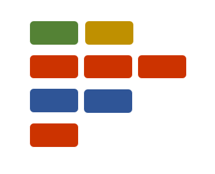

showing visual representation of a List

## 6.2 Manipulating lists

### 6.2.1 Creating Lists

Similar to vectors, to create a list we have to use a function which returns a list. In this case, the name of the function is more fitting than **`c()`** for vectors.

To create a list we will use the **`list()`** function.

Each of the contents will appear on a new line. Before each content will be its index number in double square brackets, as in [[1]], [[1]],

Index numbers simply represent the order in which each item is stored in the list.

As you can see we have various items of within our list and they all keep their data type.

```r
# Creating a list

shopping_list <- list(c("apples", "bananas", "strawberries"),
                      c(5,10,15),
                      20.2)

# To Display the list

shopping_list
```

```
## [[1]]
## [1] "apples"       "bananas"      "strawberries"
##
## [[2]]
## [1]  5 10 15
##
## [[3]]
## [1] 20.2
```

Lists are really useful, flexible data structures. Their elements can be any object we’ve seen so far and any object you might ever see - including functions!

### 6.2.2 Naming List Elements

In R certain data structures have an attribute called names. They allow us to label (or name) each element held by a data structure.

The list elements can be given names and they can be accessed using these names.

```r
# Creating a list and naming the elements

shopping_list <- list(fruits = c("apples", "bananas", "strawberries"),
                      amounts = c(5,10,15),
                      total_price = 20.2)

# To display the list

shopping_list
```

```
## $fruits
## [1] "apples"       "bananas"      "strawberries"
##
## $amounts
## [1]  5 10 15
##
## $total_price
## [1] 20.2
```

The above now displays the name associated with each element on top of the element.

We can also name our list using the **`names()`** function. This function allows us to get or set the name attribute of a data structure.

```r
# To display the names of our list

names(shopping_list)
```

```
## [1] "fruits"      "amounts"     "total_price"
```

```r
# Adding names to our items in the list

names(shopping_list)<- c("favourite_fruits", "amount_of_fruit", "total_price_of_shopping")

# To display the list

shopping_list
```

```
## $favourite_fruits
## [1] "apples"       "bananas"      "strawberries"
##
## $amount_of_fruit
## [1]  5 10 15
##
## $total_price_of_shopping
## [1] 20.2
```

As demonstrated above, lists can hold all kinds of data structures, including vectors and other lists, they can then have an interesting tree like structure which we can observe using the structure function, **`str()`** function.

The structure function will return the contents stored in the list, as well as stating the data type of each item, for example, character, numeric, vector, etc.

```r
# Checking the structure of our list using the
# str() function

str(shopping_list)
```

```
## List of 3
##  $ favourite_fruits       : chr [1:3] "apples" "bananas" "strawberries"
##  $ amount_of_fruit        : num [1:3] 5 10 15
##  $ total_price_of_shopping: num 20.2
```

### 6.2.3 Indexing a list

To access an element from the list, we have to use square brackets containing the index of the element we are after, just like for vectors.

You can select components using their name in `[[ ]]` or `$` sign (if you have a named list).

```r
# Selecting items in a list using the $ symbol

shopping_list$favourite_fruits
```

```
## [1] "apples"       "bananas"      "strawberries"
```

```r
# Selecting items in a list using the name
# for named lists

shopping_list[["favourite_fruits"]]
```

```
## [1] "apples"       "bananas"      "strawberries"
```

```r
# Selecting items in a list using the index position

shopping_list[[1]]
```

```
## [1] "apples"       "bananas"      "strawberries"
```

To return a single element or multiple elements you need to specify both the `component [[]]` and the `element[]`.These components are all vectors, and you can access an element within a vector the usual way.

```r
# Selecting items in a list using the $ symbol

shopping_list$favourite_fruits[1]
```

```
## [1] "apples"
```

```r
# Selecting items in a list using the name
# for named lists

shopping_list[["favourite_fruits"]][1]
```

```
## [1] "apples"
```

```r
# Selecting items in a list using the index position

shopping_list[[1]][1]
```

```
## [1] "apples"
```

### 6.2.4 Adding Elements to a List

Similar to vectors again, to add an element, we can either index to a blank space in the list or use the append() function:

```r
# To display the list

shopping_list
```

```
## $favourite_fruits
## [1] "apples"       "bananas"      "strawberries"
##
## $amount_of_fruit
## [1]  5 10 15
##
## $total_price_of_shopping
## [1] 20.2
```

```r
# Adding an item to a list by position

shopping_list$best_biscuits <- "custard creams"


# To display the list

shopping_list
```

```
## $favourite_fruits
## [1] "apples"       "bananas"      "strawberries"
##
## $amount_of_fruit
## [1]  5 10 15
##
## $total_price_of_shopping
## [1] 20.2
##
## $best_biscuits
## [1] "custard creams"
```

```r
# Adding an item to a list using the append function

shopping_list <- append(shopping_list, "milk")

# To display the list

shopping_list
```

```
## $favourite_fruits
## [1] "apples"       "bananas"      "strawberries"
##
## $amount_of_fruit
## [1]  5 10 15
##
## $total_price_of_shopping
## [1] 20.2
##
## $best_biscuits
## [1] "custard creams"
##
## [[5]]
## [1] "milk"
```

### 6.2.5 Exercise

#### **Exercise**

1. Create the list below.

```r
# Creating a list with multiple items

chocolate <- list(brand = "celebrations",
                  chocolate_bar = c("mars", "milky way", "bounty", "twix", "maltesers"),
                  rating = c("worst",  "terrible", "awful", "nice", "best"))
```

2. Find out the names of the list, using the `names()` function.
3. Check the structure using the `str()` function.
4. Select chocolate bars.
5. Add an item called price.

##### **Extension Exercise**

1. Select your favourite chocolate from the options.
2. Add a new chocolate bar.

#### **Show Answer**

1. Create the list below.

```r
# Creating a named list with multiple items

chocolate <- list(brand = "celebrations",
                  chocolate_bar = c("mars", "milky way", "bounty", "twix", "maltesers"),
                  rating = c("worst",  "terrible", "awful", "nice", "best"))
```

2. Find out the names of the list, using the `names()` function.

```r
# Finding the names

names(chocolate)
```

```
## [1] "brand"         "chocolate_bar" "rating"
```

3. Check the structure using the `str()` function.

```r
# Checking the structure

str(chocolate)
```

```
## List of 3
##  $ brand        : chr "celebrations"
##  $ chocolate_bar: chr [1:5] "mars" "milky way" "bounty" "twix" ...
##  $ rating       : chr [1:5] "worst" "terrible" "awful" "nice" ...
```

4. Select chocolate bars.

```r
# Select chocolate bars

chocolate$chocolate_bar
```

```
## [1] "mars"      "milky way" "bounty"    "twix"      "maltesers"
```

```r
# Updating the list by adding price

chocolate$cost <- "price"

# To display the list

chocolate
```

```
## $brand
## [1] "celebrations"
##
## $chocolate_bar
## [1] "mars"      "milky way" "bounty"    "twix"      "maltesers"
##
## $rating
## [1] "worst"    "terrible" "awful"    "nice"     "best"
##
## $cost
## [1] "price"
```

##### **Extension Exercise**

1. Select your favourite chocolate from the options.

```r
# Select my favourite chocolate bar

chocolate$chocolate_bar[3]
```

```
## [1] "bounty"
```

```r
chocolate[["chocolate_bar"]][3]
```

```
## [1] "bounty"
```

```r
chocolate[[2]][3]
```

```
## [1] "bounty"
```

```r
chocolate$chocolate_bar[5]<- "turkish delight"

# To display the list

chocolate
```

```
## $brand
## [1] "celebrations"
##
## $chocolate_bar
## [1] "mars"            "milky way"       "bounty"          "twix"
## [5] "turkish delight"
##
## $rating
## [1] "worst"    "terrible" "awful"    "nice"     "best"
##
## $cost
## [1] "price"
```

# 7 Projects

## Non-ONS

It is highly recommended to manage your R work in “projects”. When you’re starting work on a new project, choose **‘New project…’** from the File menu and **‘New Directory’** to create a directory for the project.

If you already have data related to the project in an existing directory, you can choose that option instead.

To work on this project in the future, you can select **‘Open Project…’** or **‘Recent Projects’** from the File menu and browse to the desired project.

This will ensure that your working directory will be set to the project folder, meaning you won’t have to worry about full file paths for data you are reading in or writing to that same folder.

## ONS

Within ONS, the default R working directory is within the `C:` drive.

**C drive -> My_RStudio -> Workspace**

It is good practice to organise your folders.

As shown in the example below, where you include all files to a project in the same folder `Project A`

[figure not shown]

Within the folder, it is good practice to further organise your files within folders, as shown below.

- The data folder would contain your raw and processed data.
- Images would contains any photos you are using.
- Scripts would contain all the R files. You don’t have to stick with this exact folder structure, you could add in additional folders, for example an output folder.

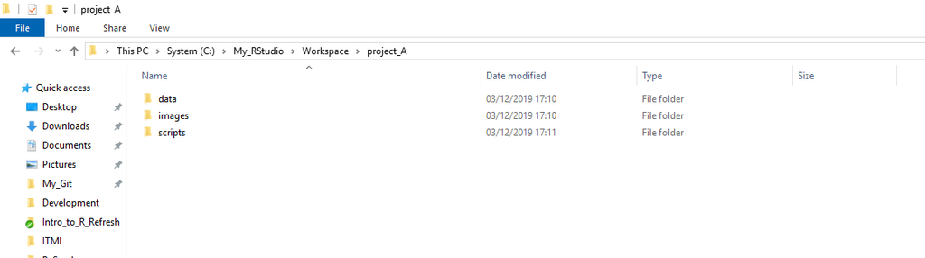

## 7.1 Relative File Paths

We can also use what’s called a relative file path to reference files.

These file paths are relative to whatever the working directory is at the time.

For example if my full or absolute location is:

```r
"C:/My_RStudio/Workspace/Intro_to_R/Data/titanic.csv"
```

This is clear and explicit about where the data is stored. However if you were to use this link you would need to change elements of it – for example you might have your `Intro_to_R` in a different folder.

I can use what’s called a relative path - the location relative to the working directory.

For example, if my working directory is `Intro_to_R`, I can load the same file as above using the path:

```r
"Data/titanic.csv"
```

Think of a file structure like a tree diagram.

From a given folder you can either move up or down the file structure.

```
Introduction_to_R
|
|
 ---Course_content
|       Intro to R - Chapter 1.Rmd
|       Intro to R - Chapter 2.Rmd
|       Intro to R - Chapter 3.Rmd
|
 ---Data
|       titanic.csv
|       police_data.xlsx
|
 ---Pre_course_information
|       ons
|       external
|
|
```

If our current working directory is `'Course_content'`, and we want to switch to `'Data'`, we can use the relative path:

```r
("../Data")
```

This effectively says, first go up a directory (`..`), so from `Course_content` to `Intro_to_R`. Then go down a directory into `Data`.

> **Going up a directory always requires `..`, whereas going down a directory always requires you to name the intended directory.**

The relative path will work for any user – as long as their working directory is set to the `'Course_content'` in the Into_to_R folder.

## 7.2 Functions Extension

### 7.2.1 Descriptive Statistics Example

For example if you wanted get the summary statistics below; We could use the summarise function.

- `min()`
- `max()`
- `mean()`
- `length()`
- `sd()`

```r
# Using Summarise function to get descriptive statistics
# We first specify our dataset using the .data arguement
# The using the descriptive statisitcs functions
# Also specify na.rm = TRUE to not include missing values
# within the calculations of the descriptive statistics

summarise(.data = titanic, minimum = min(age_of_passenger, na.rm = TRUE),
                           maximum = max(age_of_passenger, na.rm = TRUE),
                           mean = mean(age_of_passenger, na.rm = TRUE),
                           length = length(age_of_passenger),
                           standard_deviation = sd(age_of_passenger, na.rm = TRUE)
                           )
```

```
## # A tibble: 1 x 5
##   minimum maximum  mean length standard_deviation
##   <chr>   <chr>   <dbl>  <int>              <dbl>
## 1 *       9          NA   1309               14.4
```

If we wanted the same descriptive statistics for a different column we could copy and paste the code about and change the column name.

```r
# Using Summarise function to get descriptive statistics
# We first specify our dataset using the .data arguement
# The using the descriptive statisitcs functions
# Also specify na.rm = TRUE to not include missing values
# within the calculations of the descriptive statistics

summarise(.data = titanic, minimum = min(fare, na.rm = TRUE),
                           maximum = max(fare, na.rm = TRUE),
                           mean = mean(age_of_passenger, na.rm = TRUE),
                           length = length(fare),
                           standard_deviation = sd(fare, na.rm = TRUE)
                           )
```

```
## # A tibble: 1 x 5
##   minimum maximum  mean length standard_deviation
##     <dbl>   <dbl> <dbl>  <int>              <dbl>
## 1       0    512.    NA   1309               51.8
```

If we we wanted another column we could keep on copying and pasting, copying and pasting but this is not recommended as its not efficient and could lead to errors as above.

> **Did you notice the error?**

To prevent this issue we can write our own function which will combine all these descriptive statistics into one function.

- Our function name is descriptive_statistics()
- Our input will be column, which will be the column that we are interested is seeing the descriptive statistics for.
- My statements are the calculations for the descriptive statistics
- My return value will be a tibble of the descriptive statistics.

```r
# Creating my function

descriptive_statistics <- function(column){

  # Create an object "my_minimum" which contains the min of column
  column_minimum <- min(column, na.rm = TRUE)

  # Create an object "my_maximum" which contains the max of column
  column_maximum <- max(column, na.rm = TRUE)

  # Create an object "my_mean" which contains the mean of column
  column_mean <- mean(column, na.rm = TRUE)

  # Create an object "my_length" which contains the length of column
  column_length <- length(column)

  # Create an object "my_standard_deviation" which contains the sd of  column
  column_standard_deviation <- sd(column, na.rm = TRUE)

 # Combine the objects created into a tibble
 return(tibble(column_minimum,
               column_maximum,
               column_mean,
               column_length,
               column_standard_deviation)
   )
}
```

We can now use our function on different columns, without needing to copy and paste our code. Once we are confident that are function works well, we can use it multiple times safe knowing it will do exactly what we want.

```r
# Calling our function
# Here we can use it on different columns

descriptive_statistics(titanic$parch)
```

```
## # A tibble: 1 x 5
##   column_minimum column_maximum column_mean column_length column_standard_devia~
##            <dbl>          <dbl>       <dbl>         <int>                  <dbl>
## 1              0              9       0.385          1309                  0.866
```

```r
descriptive_statistics(titanic$sibsp)
```

```
## # A tibble: 1 x 5
##   column_minimum column_maximum column_mean column_length column_standard_devia~
##            <dbl>          <dbl>       <dbl>         <int>                  <dbl>
## 1              0              8       0.499          1309                   1.04
```

### 7.2.2 Applying Functions using `purrr`

Often when working with data, we want to manipulate multiple columns of data at once.

As an example using our `descriptive_statistics()` on mutliple columns at the same time - how would we achieve this?

### 7.2.3 Functionals in R

In R, functionals are functions which take a function is as an input and returns a vector (or similar) as output.

R being a functional programming language is packed with functionals. We will introduce the following:

- `purrr::map()`
- `purrr::modify()`

There are functionals in base R as well such as: `apply`, `sapply`, `lapply`, etc which are worth experimenting with as well. We will continue with our tidyverse theme and demonstrate the `purrr` equivalents.

`map()` and `modify()` will take a function in as an argument and apply it to every element of the given collection (e.g. vector, list).

As an example we can use the `typeof()` function to see the data types of each of our columns in the titanic dataset.

```r
purrr::map(titanic, typeof)
```

```
## $pclass
## [1] "double"
##
## $survived
## [1] "double"
##
## $name_of_passenger
## [1] "character"
##
## $sex_of_passenger
## [1] "character"
##
## $age_of_passenger
## [1] "character"
##
## $sibsp
## [1] "double"
##
## $parch
## [1] "double"
##
## $ticket
## [1] "character"
##
## $fare
## [1] "double"
##
## $cabin
## [1] "character"
##
## $embarked
## [1] "character"
```

In that example we used a built-in function `typeof`.

All the functionals listed above also work with user defined functions. We can even apply this using our pipe operators.

```r
titanic %>%
  dplyr::select(age_of_passenger,fare) %>%
  purrr::map(descriptive_statistics)
```

```
## $age_of_passenger
## # A tibble: 1 x 5
##   column_minimum column_maximum column_mean column_length column_standard_devia~
##   <chr>          <chr>                <dbl>         <int>                  <dbl>
## 1 *              9                       NA          1309                   14.4
##
## $fare
## # A tibble: 1 x 5
##   column_minimum column_maximum column_mean column_length column_standard_devia~
##            <dbl>          <dbl>       <dbl>         <int>                  <dbl>
## 1              0           512.        33.3          1309                   51.8
```

### 7.2.4 `map` vs `modify`

There is not a lot of difference between `map` and `modify`. `map` will return a list by default, whereas, `modify` always returns the same type as the input object.

```r
purrr::map(titanic, typeof)
```

```
## $pclass
## [1] "double"
##
## $survived
## [1] "double"
##
## $name_of_passenger
## [1] "character"
##
## $sex_of_passenger
## [1] "character"
##
## $age_of_passenger
## [1] "character"
##
## $sibsp
## [1] "double"
##
## $parch
## [1] "double"
##
## $ticket
## [1] "character"
##
## $fare
## [1] "double"
##
## $cabin
## [1] "character"
##
## $embarked
## [1] "character"
```

```r
purrr::modify(titanic, typeof)
```

```
## # A tibble: 1,309 x 11
##    pclass survived name_of_passenger sex_of_passenger age_of_passenger sibsp
##    <chr>  <chr>    <chr>             <chr>            <chr>            <chr>
##  1 double double   character         character        character        double
##  2 double double   character         character        character        double
##  3 double double   character         character        character        double
##  4 double double   character         character        character        double
##  5 double double   character         character        character        double
##  6 double double   character         character        character        double
##  7 double double   character         character        character        double
##  8 double double   character         character        character        double
##  9 double double   character         character        character        double
## 10 double double   character         character        character        double
## # ... with 1,299 more rows, and 5 more variables: parch <chr>, ticket <chr>,
## #   fare <chr>, cabin <chr>, embarked <chr>
```

As you can see, their difference sounds subtle but the effects are not.

What you prefer as an output will determine which of these you would choose to use.

# 8 Converting Coulumn types

Sometimes columns will read in with an incorrect data type.

This is usually because of an issue with the contents of a column. This can be something as simple as commas in numbers or missing values.

## 8.1 Forcing Column types on reading in data

When reading in data using `readr::read_csv` and `readxl::read_xls` you can specify the column types.

Here the entries with missing values (* and . ) will show as parsing failures but will become `n/a` missing values.

Here they are true missing values - and replacing them with `n/a` isn’t an issue - but this should be done with caution. A value of `1,0000` or `two` may cause a column to be read in as charachter but is still valid data that should be fixed before converting.

```r
titanic_2 <- readr::read_csv("../Data/titanic.csv",
                             col_types = list(`Age of passenger` = col_double()))
```

## 8.2 What are my missing values?

Using `dplyr::count()` on a column can help to identify missing values.

```r
# Read in with missing values

titanic_3 <- readr::read_csv("../Data/titanic.csv")
titanic_3 %>%
  dplyr::count(`Age of passenger`)
```

```
## # A tibble: 101 x 2
##    `Age of passenger`     n
##    <chr>              <int>
##  1 *                      2
##  2 .                      2
##  3 0.1667                 1
##  4 0.3333                 1
##  5 0.4167                 1
##  6 0.6667                 1
##  7 0.75                   3
##  8 0.8333                 3
##  9 0.9167                 2
## 10 1                     10
## # ... with 91 more rows
```

## 8.3 Converting column types after reading in

This is ideally a 3 step procedure

- Identify the error
- Fix the error
- Convert the column

As seen above the issue in the `Age of passenger` column is `*` and `.`

```r
# Fix error

titanic_3 <- titanic_3 %>%
            dplyr::mutate(`Age of passenger` = dplyr::na_if(`Age of passenger`, "*")) %>%
            dplyr::mutate(`Age of passenger` = dplyr::na_if(`Age of passenger`, "."))

# Convert column

titanic_3$`Age of passenger` <- as.numeric(titanic_3$`Age of passenger`)
```

Note that if you do convert a column to numeric without fixing the issues it will just make any character values missing values. This might be desirable but could also cause issues in your data.